# FaceWord Project – Data Analysis

[Haiyang Jin](https://haiyangjin.github.io/)

Jul 01 2021

# 1 Preparations

```r
# set the order of levels in factors
loc_order <- c("face", "object", "word", "scrambled")

faceword_order <- c("faces", "words")
words_order <- c("English", "Chinese")
layout_order <- c("intact", "exchange", "top", "bottom")
roi_order <- c("FFA1", "FFA2", "VWFA", "LO")

label_FFA1 <- c("roi.lh.f-vs-o.ffa1.label", "roi.rh.f-vs-o.ffa1.label")
label_FFA2 <- c("roi.lh.f-vs-o.ffa2.label", "roi.rh.f-vs-o.ffa2.label")
label_VWFA <- "roi.lh.word-vs-face-object-scrambled.label"
label_LO <- c("roi.lh.o-vs-scr.label", "roi.rh.o-vs-scr.label")

# criterion of vertex number
nVtx_size_min <- 30  # mm^2

decoding_sided <- "two.sided"
```

```r
# set up the theme for plot and rainclound plot
# load all the R files in "Utilities/"
tmp <- sapply(list.files('Utilities', "*.R", full.names = TRUE, recursive = TRUE), source)

activationUL <- 2.75
onesample0 <- 0.3 # the staring point of y axis (for one-sample t-tests)
nDigitals <- 3 # number of digitials of p-values in plots
```

# 2 Experiment 1: faces and Chinese characters for Chinese participants

## 2.1 Load and clean data

```r
pair_order_E1 <- c("face_intact-word_intact",
                   "face_intact-face_exchange",
                   "face_top-face_bottom",
                   "word_intact-word_exchange",
                   "word_top-word_bottom")
```

### 2.1.1 Data for univariate analyses

#### 2.1.1.1 ROI area

```r
df_area_uni_E1 <- read_csv(file.path("data_roi_area", "faceword_E1_Uni_area_HJ.csv"))
```

```r
df_clean_area_uni_E1 <- {
  df_area_uni_E1 %>%
    filter(Response != "NaN") %>%
    separate(Condition, c("FaceWord", "Layout"), "_") %>% # separate the conditions into two IVs
    mutate(FaceWord = gsub("face", "faces", FaceWord),
           FaceWord = gsub("word", "words", FaceWord),
           Layout = factor(Layout, levels = layout_order), # convert the two IVs to factors
           Hemisphere = if_else(grepl("lh", Label), "left", if_else(grepl("rh", Label), "right", "NA"))) %>%
    select(Hemisphere, Label, SessCode, FaceWord, Layout, Area, Response) %>%
    mutate(Subject = str_replace(SessCode, "\\_.*", ""))
}

head(df_clean_area_uni_E1)
```

| Hemisphere | Label | SessCode | FaceWord | Layout | Area | Response | Subject |
| --- | --- | --- | --- | --- | --- | --- | --- |
| left | roi.lh.f-vs-o.ffa1.surf.geodesic.a50.label | faceword03_self | faces | intact | 50 | 1.1320453 | faceword03 |
| left | roi.lh.f-vs-o.ffa1.surf.geodesic.a50.label | faceword03_self | faces | exchange | 50 | 0.9362864 | faceword03 |
| left | roi.lh.f-vs-o.ffa1.surf.geodesic.a50.label | faceword03_self | faces | top | 50 | 0.9014562 | faceword03 |
| left | roi.lh.f-vs-o.ffa1.surf.geodesic.a50.label | faceword03_self | faces | bottom | 50 | 0.6518343 | faceword03 |
| left | roi.lh.f-vs-o.ffa1.surf.geodesic.a50.label | faceword03_self | words | intact | 50 | 1.0542056 | faceword03 |
| left | roi.lh.f-vs-o.ffa1.surf.geodesic.a50.label | faceword03_self | words | exchange | 50 | 1.1507695 | faceword03 |

### 2.1.2 Data of decoding

#### 2.1.2.1 ROI area

```r
df_decode_area_E1 <- read_csv(file.path("data_roi_area", "faceword_roi_area_E1_Decode_noz.csv"))

head(df_decode_area_E1)
```

| Label | Analysis | nVertices | SessCode | ClassifyPair | Classifier | Run | Predicted | Targets | ACC |
| --- | --- | --- | --- | --- | --- | --- | --- | --- | --- |
| roi.lh.f-vs-o.ffa1.surf.geodesic.a50.label | main_sm0_E1_self.lh | 71 | faceword03_self | face_intact-word_intact | cosmo_classify_libsvm | 1 | 1 | 1 | 1 |
| roi.lh.f-vs-o.ffa1.surf.geodesic.a50.label | main_sm0_E1_self.lh | 71 | faceword03_self | face_intact-word_intact | cosmo_classify_libsvm | 1 | 5 | 5 | 1 |
| roi.lh.f-vs-o.ffa1.surf.geodesic.a50.label | main_sm0_E1_self.lh | 71 | faceword03_self | face_intact-word_intact | cosmo_classify_libsvm | 2 | 5 | 1 | 0 |
| roi.lh.f-vs-o.ffa1.surf.geodesic.a50.label | main_sm0_E1_self.lh | 71 | faceword03_self | face_intact-word_intact | cosmo_classify_libsvm | 2 | 5 | 5 | 1 |
| roi.lh.f-vs-o.ffa1.surf.geodesic.a50.label | main_sm0_E1_self.lh | 71 | faceword03_self | face_intact-word_intact | cosmo_classify_libsvm | 3 | 1 | 1 | 1 |
| roi.lh.f-vs-o.ffa1.surf.geodesic.a50.label | main_sm0_E1_self.lh | 71 | faceword03_self | face_intact-word_intact | cosmo_classify_libsvm | 3 | 1 | 5 | 0 |

```r
df_decode_area_acc_E1 <- df_decode_area_E1 %>%
  select(Label, SessCode, ClassifyPair, ACC) %>%
  mutate(Hemisphere = if_else(grepl("lh", Label), "left",
                              if_else(grepl("rh", Label), "right", "NA")),
         Area = str_extract(Label, "a\\d"), # find the area
         Subject = str_remove(SessCode, "\\_.*")) %>%
  group_by(Hemisphere, Label, SessCode, ClassifyPair) %>% # divide the data into groups by these columns
  summarize(Accuracy = mean(ACC), Count = n()) %>%
  ungroup()

df_decode_area_acc_E1
```

| Hemisphere | Label | SessCode | ClassifyPair | Accuracy | Count |
| --- | --- | --- | --- | --- | --- |
| left | roi.lh.f-vs-o.ffa1.surf.geodesic.a100.label | faceword03_self | face_intact-face_exchange | 0.50 | 20 |
| left | roi.lh.f-vs-o.ffa1.surf.geodesic.a100.label | faceword03_self | face_intact-word_intact | 0.55 | 20 |
| left | roi.lh.f-vs-o.ffa1.surf.geodesic.a100.label | faceword03_self | face_top-face_bottom | 0.40 | 20 |
| left | roi.lh.f-vs-o.ffa1.surf.geodesic.a100.label | faceword03_self | word_intact-word_exchange | 0.40 | 20 |
| left | roi.lh.f-vs-o.ffa1.surf.geodesic.a100.label | faceword03_self | word_top-word_bottom | 0.65 | 20 |
| left | roi.lh.f-vs-o.ffa1.surf.geodesic.a100.label | faceword04_self | face_intact-face_exchange | 0.40 | 20 |
| left | roi.lh.f-vs-o.ffa1.surf.geodesic.a100.label | faceword04_self | face_intact-word_intact | 0.60 | 20 |
| left | roi.lh.f-vs-o.ffa1.surf.geodesic.a100.label | faceword04_self | face_top-face_bottom | 0.35 | 20 |
| left | roi.lh.f-vs-o.ffa1.surf.geodesic.a100.label | faceword04_self | word_intact-word_exchange | 0.60 | 20 |
| left | roi.lh.f-vs-o.ffa1.surf.geodesic.a100.label | faceword04_self | word_top-word_bottom | 0.35 | 20 |

[output cut: 2230 more lines]

## 2.2 Label:FFA1

### 2.2.1 Univariate analyses

#### 2.2.1.1 rm-ANOVA

##### 2.2.1.1.1 Left FFA1

Area

```r
anova_E1_lFFA1_area <- aov_4(Response ~ FaceWord * Layout * Area + (FaceWord * Layout * Area | Subject),
                                data = df_clean_area_uni_E1 %>%
                                  filter(grepl("lh.f-vs-o.ffa1", Label)))
```

```r
contrast(emmeans(anova_E1_lFFA1_area, ~ Layout + FaceWord | Area), interaction="pairwise", adjust="none", infer = TRUE)[seq(1,24,6)]
```

```
##  Layout_pairwise   FaceWord_pairwise Area estimate     SE   df lower.CL upper.CL t.ratio p.value
##  intact - exchange faces - words     X50     0.259 0.0755 39.5   0.1063    0.412 3.429   0.0014
##  intact - exchange faces - words     X100    0.230 0.0755 39.5   0.0776    0.383 3.050   0.0041
##  intact - exchange faces - words     X200    0.194 0.0755 39.5   0.0416    0.347 2.573   0.0140
##  intact - exchange faces - words     X300    0.170 0.0755 39.5   0.0170    0.322 2.247   0.0303
##
## Confidence level used: 0.95
```

```r
(sim_area_E1_lFFA1 <-contrast(emmeans(anova_E1_lFFA1_area, ~ Layout | FaceWord + Area),
                                 "pairwise", adjust="none", infer = TRUE)[c(seq(1,48,6), seq(6,48,6))])
```

```
##  contrast          FaceWord Area estimate    SE   df  lower.CL upper.CL t.ratio p.value
##  intact - exchange faces    X50   0.17561 0.057 75.8  0.062113   0.2891  3.082  0.0029
##  intact - exchange words    X50  -0.08331 0.057 75.8 -0.196815   0.0302 -1.462  0.1479
##  intact - exchange faces    X100  0.14884 0.057 75.8  0.035342   0.2623  2.612  0.0108
##  intact - exchange words    X100 -0.08142 0.057 75.8 -0.194921   0.0321 -1.429  0.1572
##  intact - exchange faces    X200  0.11314 0.057 75.8 -0.000363   0.2266  1.985  0.0507
##  intact - exchange words    X200 -0.08113 0.057 75.8 -0.194633   0.0324 -1.424  0.1586
##  intact - exchange faces    X300  0.08525 0.057 75.8 -0.028252   0.1987  1.496  0.1388
##  intact - exchange words    X300 -0.08438 0.057 75.8 -0.197879   0.0291 -1.481  0.1428
##  top - bottom      faces    X50   0.07517 0.057 75.8 -0.038329   0.1887  1.319  0.1911
##  top - bottom      words    X50  -0.15512 0.057 75.8 -0.268625  -0.0416 -2.722  0.0080
##  top - bottom      faces    X100  0.05278 0.057 75.8 -0.060724   0.1663  0.926  0.3573
##  top - bottom      words    X100 -0.15446 0.057 75.8 -0.267961  -0.0410 -2.711  0.0083
##  top - bottom      faces    X200  0.01539 0.057 75.8 -0.098108   0.1289  0.270  0.7878
##  top - bottom      words    X200 -0.14879 0.057 75.8 -0.262292  -0.0353 -2.611  0.0109
##  top - bottom      faces    X300 -0.00852 0.057 75.8 -0.122025   0.1050 -0.150  0.8815
##  top - bottom      words    X300 -0.14360 0.057 75.8 -0.257101  -0.0301 -2.520  0.0138
##
## Confidence level used: 0.95
```

##### 2.2.1.1.2 Right FFA1

Area

```r
anova_E1_rFFA1_area <- aov_4(Response ~ FaceWord * Layout * Area + (FaceWord * Layout * Area | Subject),
                                data = df_clean_area_uni_E1 %>%
                                  filter(grepl("rh.f-vs-o.ffa1", Label)))
```

```r
contrast(emmeans(anova_E1_rFFA1_area, ~ Layout + FaceWord | Area), interaction="pairwise", adjust="none", infer = TRUE)[seq(1,24,6)]
```

```
##  Layout_pairwise   FaceWord_pairwise Area estimate     SE   df lower.CL upper.CL t.ratio p.value
##  intact - exchange faces - words     X50     0.283 0.0934 51.3  0.09568    0.471 3.032   0.0038
##  intact - exchange faces - words     X100    0.263 0.0934 51.3  0.07560    0.450 2.817   0.0069
##  intact - exchange faces - words     X200    0.226 0.0934 51.3  0.03813    0.413 2.416   0.0193
##  intact - exchange faces - words     X300    0.194 0.0934 51.3  0.00691    0.382 2.081   0.0424
##
## Confidence level used: 0.95
```

```r
(sim_area_E1_rFFA1 <- contrast(emmeans(anova_E1_rFFA1_area, ~ Layout | FaceWord + Area), "pairwise", adjust="none", infer = TRUE)[c(seq(1,48,6), seq(6,48,6))])
```

```
##  contrast          FaceWord Area estimate     SE  df lower.CL upper.CL t.ratio p.value
##  intact - exchange faces    X50   0.31965 0.0647 103   0.1913   0.4480  4.938  <.0001
##  intact - exchange words    X50   0.03656 0.0647 103  -0.0918   0.1649  0.565  0.5735
##  intact - exchange faces    X100  0.28016 0.0647 103   0.1518   0.4085  4.328  <.0001
##  intact - exchange words    X100  0.01714 0.0647 103  -0.1112   0.1455  0.265  0.7917
##  intact - exchange faces    X200  0.22342 0.0647 103   0.0950   0.3518  3.452  0.0008
##  intact - exchange words    X200 -0.00213 0.0647 103  -0.1305   0.1263 -0.033  0.9739
##  intact - exchange faces    X300  0.18547 0.0647 103   0.0571   0.3139  2.865  0.0051
##  intact - exchange words    X300 -0.00885 0.0647 103  -0.1372   0.1195 -0.137  0.8915
##  top - bottom      faces    X50   0.02072 0.0647 103  -0.1077   0.1491  0.320  0.7496
##  top - bottom      words    X50  -0.03171 0.0647 103  -0.1601   0.0967 -0.490  0.6253
##  top - bottom      faces    X100  0.00865 0.0647 103  -0.1197   0.1370  0.134  0.8939
##  top - bottom      words    X100 -0.03515 0.0647 103  -0.1635   0.0932 -0.543  0.5882
##  top - bottom      faces    X200 -0.00199 0.0647 103  -0.1304   0.1264 -0.031  0.9755
##  top - bottom      words    X200 -0.02865 0.0647 103  -0.1570   0.0997 -0.443  0.6590
##  top - bottom      faces    X300 -0.00213 0.0647 103  -0.1305   0.1263 -0.033  0.9738
##  top - bottom      words    X300 -0.02084 0.0647 103  -0.1492   0.1075 -0.322  0.7482
##
## Confidence level used: 0.95
```

### 2.2.2 Decoding

Area

```r
# one-sample for results of decode E1 FFA1
one_decode_area_agg_E1_FFA1 <- {
  df_decode_area_acc_E1 %>%
    filter(grepl("f-vs-o.ffa1", Label)) %>%
    mutate(ClassifyPair = fct_relevel(ClassifyPair, pair_order_E1),
           Area = as.numeric(str_extract(Label, "\\d*0"))) %>%
    group_by(Hemisphere, ClassifyPair, Area) %>%
    summarize(mean = t.test(Accuracy, mu = 0.5, alternative = decoding_sided)[[5]],
              SE = t.test(Accuracy, mu = 0.5, alternative = decoding_sided)[[7]],
              cohens_d = (mean-0.5)/sd(Accuracy),
              t = t.test(Accuracy, mu = 0.5, alternative = decoding_sided)[[1]],
              df = t.test(Accuracy, mu = 0.5, alternative = decoding_sided)[[2]],
              p = round(t.test(Accuracy, mu = 0.5, alternative = decoding_sided)[[3]], 5),
              lower.CL = t.test(Accuracy, mu = 0.5, alternative = decoding_sided)[[4]][1],
              upper.CL = mean * 2 - lower.CL, # t.test(Accuracy, mu = 0.5, alternative = "two.sided")[[4]][2],
              nullValue = t.test(Accuracy, mu = 0.5, alternative = decoding_sided)[[6]],
              alternative = t.test(Accuracy, mu = 0.5, alternative = decoding_sided)[[8]]
    )
}

one_decode_area_agg_E1_FFA1
```

| Hemisphere | ClassifyPair | Area | mean | SE | cohens_d | t | df | p | lower.CL | upper.CL | nullValue | alternative |
| --- | --- | --- | --- | --- | --- | --- | --- | --- | --- | --- | --- | --- |
| left | face_intact-word_intact | 50 | 0.6769231 | 0.03695778 | 1.32772123 | 4.7871670 | 12 | 0.00044 | 0.5963990 | 0.7574472 | 0.5 | two.sided |
| left | face_intact-word_intact | 100 | 0.6961538 | 0.04254015 | 1.27886910 | 4.6110281 | 12 | 0.00060 | 0.6034668 | 0.7888409 | 0.5 | two.sided |
| left | face_intact-word_intact | 200 | 0.7692308 | 0.03778247 | 1.97634476 | 7.1258124 | 12 | 0.00001 | 0.6869098 | 0.8515517 | 0.5 | two.sided |
| left | face_intact-word_intact | 300 | 0.7884615 | 0.03210252 | 2.49216660 | 8.9856345 | 12 | 0.00000 | 0.7185161 | 0.8584069 | 0.5 | two.sided |
| left | face_intact-face_exchange | 50 | 0.4576923 | 0.03956743 | -0.29655809 | -1.0692554 | 12 | 0.30599 | 0.3714823 | 0.5439023 | 0.5 | two.sided |
| left | face_intact-face_exchange | 100 | 0.4653846 | 0.02962621 | -0.32405704 | -1.1684043 | 12 | 0.26533 | 0.4008347 | 0.5299346 | 0.5 | two.sided |
| left | face_intact-face_exchange | 200 | 0.4653846 | 0.03685758 | -0.26047777 | -0.9391659 | 12 | 0.36617 | 0.3850788 | 0.5456904 | 0.5 | two.sided |
| left | face_intact-face_exchange | 300 | 0.5192308 | 0.03179384 | 0.16775753 | 0.6048584 | 12 | 0.55654 | 0.4499579 | 0.5885036 | 0.5 | two.sided |
| left | face_top-face_bottom | 50 | 0.5115385 | 0.02603858 | 0.12290197 | 0.4431294 | 12 | 0.66556 | 0.4548053 | 0.5682717 | 0.5 | two.sided |
| left | face_top-face_bottom | 100 | 0.5115385 | 0.04049131 | 0.07903408 | 0.2849614 | 12 | 0.78053 | 0.4233155 | 0.5997615 | 0.5 | two.sided |

[output cut: 30 more lines]

lFFA1 word_intact vs. word_exchange is significantly above chance (300 mm^2).

rFFA1 face_intact vs. face_exchange is marginally (p = 0.05021) above chance (50 mm^2).

## 2.3 Label:FFA2

### 2.3.1 Univariate analyses

#### 2.3.1.1 rm-ANOVA

##### 2.3.1.1.1 Left FFA2

Area

```r
anova_E1_lFFA2_area <- aov_4(Response ~ FaceWord * Layout * Area + (FaceWord * Layout * Area | Subject),
                                data = df_clean_area_uni_E1 %>%
                                  filter(grepl("lh.f-vs-o.ffa2", Label)))
```

```r
contrast(emmeans(anova_E1_lFFA2_area, ~ Layout + FaceWord | Area), interaction="pairwise", adjust="none", infer = TRUE)[seq(1,24,6)]
```

```
##  Layout_pairwise   FaceWord_pairwise Area estimate   SE   df lower.CL upper.CL t.ratio p.value
##  intact - exchange faces - words     X50    0.1011 0.09 38.1  -0.0812    0.283 1.123   0.2686
##  intact - exchange faces - words     X100   0.0822 0.09 38.1  -0.1001    0.264 0.912   0.3673
##  intact - exchange faces - words     X200   0.0731 0.09 38.1  -0.1091    0.255 0.812   0.4217
##  intact - exchange faces - words     X300   0.0750 0.09 38.1  -0.1072    0.257 0.833   0.4098
##
## Confidence level used: 0.95
```

```r
(sim_area_E1_lFFA2 <- contrast(emmeans(anova_E1_lFFA2_area, ~ Layout | FaceWord + Area), "pairwise", adjust="none", infer = TRUE)[c(seq(1,48,6), seq(6,48,6))])
```

```
##  contrast          FaceWord Area estimate     SE   df lower.CL  upper.CL t.ratio p.value
##  intact - exchange faces    X50   0.10582 0.0541 66.8 -0.00219  0.213829  1.956  0.0547
##  intact - exchange words    X50   0.00473 0.0541 66.8 -0.10328  0.112740  0.087  0.9306
##  intact - exchange faces    X100  0.09678 0.0541 66.8 -0.01123  0.204784  1.789  0.0782
##  intact - exchange words    X100  0.01462 0.0541 66.8 -0.09338  0.122633  0.270  0.7878
##  intact - exchange faces    X200  0.08636 0.0541 66.8 -0.02165  0.194363  1.596  0.1152
##  intact - exchange words    X200  0.01322 0.0541 66.8 -0.09478  0.121232  0.244  0.8077
##  intact - exchange faces    X300  0.08504 0.0541 66.8 -0.02297  0.193047  1.572  0.1208
##  intact - exchange words    X300  0.01000 0.0541 66.8 -0.09801  0.118009  0.185  0.8539
##  top - bottom      faces    X50  -0.06560 0.0541 66.8 -0.17361  0.042411 -1.212  0.2297
##  top - bottom      words    X50  -0.09073 0.0541 66.8 -0.19873  0.017282 -1.677  0.0983
##  top - bottom      faces    X100 -0.05740 0.0541 66.8 -0.16541  0.050604 -1.061  0.2926
##  top - bottom      words    X100 -0.10334 0.0541 66.8 -0.21135  0.004669 -1.910  0.0605
##  top - bottom      faces    X200 -0.04542 0.0541 66.8 -0.15343  0.062590 -0.839  0.4043
##  top - bottom      words    X200 -0.11398 0.0541 66.8 -0.22199 -0.005971 -2.106  0.0389
##  top - bottom      faces    X300 -0.03772 0.0541 66.8 -0.14573  0.070290 -0.697  0.4882
##  top - bottom      words    X300 -0.10897 0.0541 66.8 -0.21698 -0.000963 -2.014  0.0480
##
## Confidence level used: 0.95
```

##### 2.3.1.1.2 Right FFA2

Area

```r
anova_E1_rFFA2_area <- aov_4(Response ~ FaceWord * Layout * Area + (FaceWord * Layout * Area | Subject),
                                data = df_clean_area_uni_E1 %>%
                                  filter(grepl("rh.f-vs-o.ffa2", Label)))
```

```r
contrast(emmeans(anova_E1_rFFA2_area, ~ Layout + FaceWord | Area), interaction="pairwise", adjust="none", infer = TRUE)[seq(1,24,6)]
```

```
##  Layout_pairwise   FaceWord_pairwise Area estimate    SE   df lower.CL upper.CL t.ratio p.value
##  intact - exchange faces - words     X50     0.243 0.081 42.4   0.0794    0.406 2.998   0.0045
##  intact - exchange faces - words     X100    0.231 0.081 42.4   0.0673    0.394 2.848   0.0068
##  intact - exchange faces - words     X200    0.195 0.081 42.4   0.0319    0.359 2.412   0.0203
##  intact - exchange faces - words     X300    0.185 0.081 42.4   0.0212    0.348 2.280   0.0277
##
## Confidence level used: 0.95
```

```r
(sim_area_E1_rFFA2 <- contrast(emmeans(anova_E1_rFFA2_area, ~ Layout | FaceWord + Area), "pairwise", adjust="none", infer = TRUE)[c(seq(1,48,6), seq(6,48,6))])
```

```
##  contrast          FaceWord Area estimate     SE   df lower.CL upper.CL t.ratio p.value
##  intact - exchange faces    X50    0.3223 0.0563 84.7   0.2103   0.4343  5.720  <.0001
##  intact - exchange words    X50    0.0795 0.0563 84.7  -0.0325   0.1915  1.411  0.1620
##  intact - exchange faces    X100   0.2965 0.0563 84.7   0.1844   0.4085  5.262  <.0001
##  intact - exchange words    X100   0.0658 0.0563 84.7  -0.0462   0.1778  1.168  0.2462
##  intact - exchange faces    X200   0.2476 0.0563 84.7   0.1355   0.3596  4.394  <.0001
##  intact - exchange words    X200   0.0522 0.0563 84.7  -0.0598   0.1643  0.927  0.3564
##  intact - exchange faces    X300   0.2194 0.0563 84.7   0.1074   0.3315  3.895  0.0002
##  intact - exchange words    X300   0.0348 0.0563 84.7  -0.0772   0.1468  0.618  0.5385
##  top - bottom      faces    X50   -0.0500 0.0563 84.7  -0.1621   0.0620 -0.888  0.3770
##  top - bottom      words    X50   -0.0582 0.0563 84.7  -0.1702   0.0538 -1.033  0.3044
##  top - bottom      faces    X100  -0.0463 0.0563 84.7  -0.1584   0.0657 -0.823  0.4130
##  top - bottom      words    X100  -0.0568 0.0563 84.7  -0.1689   0.0552 -1.008  0.3161
##  top - bottom      faces    X200  -0.0510 0.0563 84.7  -0.1630   0.0610 -0.906  0.3678
##  top - bottom      words    X200  -0.0387 0.0563 84.7  -0.1507   0.0733 -0.687  0.4940
##  top - bottom      faces    X300  -0.0487 0.0563 84.7  -0.1607   0.0634 -0.864  0.3902
##  top - bottom      words    X300  -0.0243 0.0563 84.7  -0.1363   0.0877 -0.431  0.6676
##
## Confidence level used: 0.95
```

### 2.3.2 Decoding

Area

```r
# one-sample for results of decode E1 FFA2
one_decode_area_agg_E1_FFA2<- {
  df_decode_area_acc_E1 %>%
    filter(grepl("f-vs-o.ffa2", Label)) %>%
    mutate(ClassifyPair = fct_relevel(ClassifyPair, pair_order_E1),
           Area = as.numeric(str_extract(Label, "\\d*0"))) %>%
    group_by(Hemisphere, ClassifyPair, Area) %>%
    summarize(mean = t.test(Accuracy, mu = 0.5, alternative = decoding_sided)[[5]],
              SE = t.test(Accuracy, mu = 0.5, alternative = decoding_sided)[[7]],
              cohens_d = (mean-0.5)/sd(Accuracy),
              t = t.test(Accuracy, mu = 0.5, alternative = decoding_sided)[[1]],
              df = t.test(Accuracy, mu = 0.5, alternative = decoding_sided)[[2]],
              p = round(t.test(Accuracy, mu = 0.5, alternative = decoding_sided)[[3]], 5),
              lower.CL = t.test(Accuracy, mu = 0.5, alternative = decoding_sided)[[4]][1],
              upper.CL = mean * 2 - lower.CL, # t.test(Accuracy, mu = 0.5, alternative = "two.sided")[[4]][2],
              nullValue = t.test(Accuracy, mu = 0.5, alternative = decoding_sided)[[6]],
              alternative = t.test(Accuracy, mu = 0.5, alternative = decoding_sided)[[8]]
    )
}

one_decode_area_agg_E1_FFA2
```

| Hemisphere | ClassifyPair | Area | mean | SE | cohens_d | t | df | p | lower.CL | upper.CL | nullValue | alternative |
| --- | --- | --- | --- | --- | --- | --- | --- | --- | --- | --- | --- | --- |
| left | face_intact-word_intact | 50 | 0.6384615 | 0.02477711 | 1.54991106 | 5.58828379 | 12 | 0.00012 | 0.5844768 | 0.6924462 | 0.5 | two.sided |
| left | face_intact-word_intact | 100 | 0.6923077 | 0.02646124 | 2.01564842 | 7.26752375 | 12 | 0.00001 | 0.6346536 | 0.7499618 | 0.5 | two.sided |
| left | face_intact-word_intact | 200 | 0.7730769 | 0.03472206 | 2.18126217 | 7.86465261 | 12 | 0.00000 | 0.6974241 | 0.8487298 | 0.5 | two.sided |
| left | face_intact-word_intact | 300 | 0.7807692 | 0.03648782 | 2.13417451 | 7.69487564 | 12 | 0.00001 | 0.7012691 | 0.8602694 | 0.5 | two.sided |
| left | face_intact-face_exchange | 50 | 0.5307692 | 0.03076923 | 0.27735010 | 1.00000000 | 12 | 0.33705 | 0.4637288 | 0.5978096 | 0.5 | two.sided |
| left | face_intact-face_exchange | 100 | 0.5230769 | 0.03518057 | 0.18192959 | 0.65595647 | 12 | 0.52423 | 0.4464250 | 0.5997288 | 0.5 | two.sided |
| left | face_intact-face_exchange | 200 | 0.5884615 | 0.04907929 | 0.49990157 | 1.80242075 | 12 | 0.09663 | 0.4815269 | 0.6953961 | 0.5 | two.sided |
| left | face_intact-face_exchange | 300 | 0.5923077 | 0.04962880 | 0.51586070 | 1.85996222 | 12 | 0.08757 | 0.4841758 | 0.7004396 | 0.5 | two.sided |
| left | face_top-face_bottom | 50 | 0.4961538 | 0.04438379 | -0.02403425 | -0.08665672 | 12 | 0.93237 | 0.3994499 | 0.5928578 | 0.5 | two.sided |
| left | face_top-face_bottom | 100 | 0.4692308 | 0.04887794 | -0.17459510 | -0.62951158 | 12 | 0.54081 | 0.3627349 | 0.5757267 | 0.5 | two.sided |

[output cut: 30 more lines]

## 2.4 Label: left Visual Word Form Area (VWFA)

### 2.4.1 Univariate analyses

#### 2.4.1.1 rm-ANOVA

Area

```r
anova_E1_VWFA_area <- aov_4(Response ~ FaceWord * Layout * Area + (FaceWord * Layout * Area | Subject),
                                data = df_clean_area_uni_E1 %>%
                                  filter(grepl("lh.word-vs-face-object-scrambled", Label)))
```

```r
contrast(emmeans(anova_E1_VWFA_area, ~ Layout + FaceWord | Area), interaction="pairwise", adjust="none", infer = TRUE)[seq(1,24,6)]
```

```
##  Layout_pairwise   FaceWord_pairwise Area estimate     SE   df lower.CL upper.CL t.ratio p.value
##  intact - exchange faces - words     X50     0.230 0.0616 54.6   0.1064    0.354 3.730   0.0005
##  intact - exchange faces - words     X100    0.213 0.0616 54.6   0.0899    0.337 3.462   0.0010
##  intact - exchange faces - words     X200    0.192 0.0616 54.6   0.0681    0.315 3.109   0.0030
##  intact - exchange faces - words     X300    0.175 0.0616 54.6   0.0518    0.299 2.844   0.0063
##
## Confidence level used: 0.95
```

```r
(sim_area_E1_VWFA <- contrast(emmeans(anova_E1_VWFA_area, ~ Layout | FaceWord + Area), "pairwise", adjust="none", infer = TRUE)[c(seq(1,48,6), seq(6,48,6))])
```

```
##  contrast          FaceWord Area estimate     SE  df lower.CL upper.CL t.ratio p.value
##  intact - exchange faces    X50    0.0567 0.0465 108  -0.0355   0.1489  1.219  0.2254
##  intact - exchange words    X50   -0.1732 0.0465 108  -0.2654  -0.0810 -3.724  0.0003
##  intact - exchange faces    X100   0.0593 0.0465 108  -0.0329   0.1515  1.275  0.2050
##  intact - exchange words    X100  -0.1541 0.0465 108  -0.2463  -0.0619 -3.314  0.0013
##  intact - exchange faces    X200   0.0654 0.0465 108  -0.0268   0.1576  1.407  0.1624
##  intact - exchange words    X200  -0.1262 0.0465 108  -0.2184  -0.0340 -2.714  0.0078
##  intact - exchange faces    X300   0.0676 0.0465 108  -0.0246   0.1598  1.453  0.1491
##  intact - exchange words    X300  -0.1077 0.0465 108  -0.1999  -0.0155 -2.316  0.0225
##  top - bottom      faces    X50    0.0495 0.0465 108  -0.0428   0.1417  1.063  0.2901
##  top - bottom      words    X50   -0.1588 0.0465 108  -0.2510  -0.0666 -3.413  0.0009
##  top - bottom      faces    X100   0.0334 0.0465 108  -0.0588   0.1256  0.718  0.4744
##  top - bottom      words    X100  -0.1451 0.0465 108  -0.2373  -0.0529 -3.120  0.0023
##  top - bottom      faces    X200   0.0200 0.0465 108  -0.0722   0.1122  0.431  0.6675
##  top - bottom      words    X200  -0.1237 0.0465 108  -0.2159  -0.0315 -2.659  0.0090
##  top - bottom      faces    X300   0.0104 0.0465 108  -0.0818   0.1026  0.224  0.8234
##  top - bottom      words    X300  -0.1095 0.0465 108  -0.2017  -0.0173 -2.354  0.0204
##
## Confidence level used: 0.95
```

### 2.4.2 Decoding

Area

```r
# one-sample for results of decode E1 VWFA
one_decode_area_agg_E1_VWFA<- {
  df_decode_area_acc_E1 %>%
    filter(grepl("lh.word-vs-face-object-scrambled", Label)) %>%
    mutate(ClassifyPair = fct_relevel(ClassifyPair, pair_order_E1),
           Area = as.numeric(str_extract(Label, "\\d*0"))) %>%
    group_by(Hemisphere, ClassifyPair, Area) %>%
    summarize(mean = t.test(Accuracy, mu = 0.5, alternative = decoding_sided)[[5]],
              SE = t.test(Accuracy, mu = 0.5, alternative = decoding_sided)[[7]],
              cohens_d = (mean-0.5)/sd(Accuracy),
              t = t.test(Accuracy, mu = 0.5, alternative = decoding_sided)[[1]],
              df = t.test(Accuracy, mu = 0.5, alternative = decoding_sided)[[2]],
              p = round(t.test(Accuracy, mu = 0.5, alternative = decoding_sided)[[3]], 5),
              lower.CL = t.test(Accuracy, mu = 0.5, alternative = decoding_sided)[[4]][1],
              upper.CL = mean * 2 - lower.CL, # t.test(Accuracy, mu = 0.5, alternative = "two.sided")[[4]][2],
              nullValue = t.test(Accuracy, mu = 0.5, alternative = decoding_sided)[[6]],
              alternative = t.test(Accuracy, mu = 0.5, alternative = decoding_sided)[[8]]
    )
}

one_decode_area_agg_E1_VWFA
```

| Hemisphere | ClassifyPair | Area | mean | SE | cohens_d | t | df | p | lower.CL | upper.CL | nullValue | alternative |
| --- | --- | --- | --- | --- | --- | --- | --- | --- | --- | --- | --- | --- |
| left | face_intact-word_intact | 50 | 0.7250000 | 0.03965744 | 1.33727772 | 5.6735888 | 17 | 0.00003 | 0.6413301 | 0.8086699 | 0.5 | two.sided |
| left | face_intact-word_intact | 100 | 0.7250000 | 0.03924325 | 1.35139186 | 5.7334701 | 17 | 0.00002 | 0.6422040 | 0.8077960 | 0.5 | two.sided |
| left | face_intact-word_intact | 200 | 0.7750000 | 0.04067446 | 1.59358281 | 6.7609993 | 17 | 0.00000 | 0.6891844 | 0.8608156 | 0.5 | two.sided |
| left | face_intact-word_intact | 300 | 0.7750000 | 0.04027073 | 1.60955898 | 6.8287804 | 17 | 0.00000 | 0.6900362 | 0.8599638 | 0.5 | two.sided |
| left | face_intact-face_exchange | 50 | 0.4555556 | 0.03154230 | -0.33211456 | -1.4090427 | 17 | 0.17685 | 0.3890071 | 0.5221040 | 0.5 | two.sided |
| left | face_intact-face_exchange | 100 | 0.5000000 | 0.02556550 | 0.00000000 | 0.0000000 | 17 | 1.00000 | 0.4460615 | 0.5539385 | 0.5 | two.sided |
| left | face_intact-face_exchange | 200 | 0.5055556 | 0.03075544 | 0.04257644 | 0.1806365 | 17 | 0.85879 | 0.4406673 | 0.5704439 | 0.5 | two.sided |
| left | face_intact-face_exchange | 300 | 0.4916667 | 0.03031695 | -0.06478835 | -0.2748737 | 17 | 0.78673 | 0.4277035 | 0.5556298 | 0.5 | two.sided |
| left | face_top-face_bottom | 50 | 0.4722222 | 0.03239418 | -0.20211302 | -0.8574929 | 17 | 0.40310 | 0.4038765 | 0.5405680 | 0.5 | two.sided |
| left | face_top-face_bottom | 100 | 0.4694444 | 0.03055556 | -0.23570226 | -1.0000000 | 17 | 0.33133 | 0.4049779 | 0.5339110 | 0.5 | two.sided |

[output cut: 10 more lines]

VWFA: word_intact vs. word_exchange significant above chance (100, 300mm^2).

## 2.5 Label:Lateral Occipital Cortex

### 2.5.1 Univariate analyses

#### 2.5.1.1 rm-ANOVA

##### 2.5.1.1.1 Left LO

Area

```r
anova_E1_lLO_area <- aov_4(Response ~ FaceWord * Layout * Area + (FaceWord * Layout * Area | Subject),
                                data = df_clean_area_uni_E1 %>%
                                  filter(grepl("lh.o-vs-scr", Label)))
```

```r
contrast(emmeans(anova_E1_lLO_area, ~ Layout + FaceWord | Area), interaction="pairwise", adjust="none", infer = TRUE)[seq(1,24,6)]
```

```
##  Layout_pairwise   FaceWord_pairwise Area estimate     SE   df lower.CL upper.CL t.ratio p.value
##  intact - exchange faces - words     X50   0.00334 0.0725 56.5   -0.142    0.148 0.046   0.9634
##  intact - exchange faces - words     X100  0.01430 0.0725 56.5   -0.131    0.159 0.197   0.8443
##  intact - exchange faces - words     X200  0.02400 0.0725 56.5   -0.121    0.169 0.331   0.7418
##  intact - exchange faces - words     X300  0.02942 0.0725 56.5   -0.116    0.175 0.406   0.6863
##
## Confidence level used: 0.95
```

```r
(sim_area_E1_lLO <- contrast(emmeans(anova_E1_lLO_area, ~ Layout | FaceWord + Area), "pairwise", adjust="none", infer = TRUE)[c(seq(1,48,6), seq(6,48,6))])
```

```
##  contrast          FaceWord Area estimate     SE  df lower.CL upper.CL t.ratio p.value
##  intact - exchange faces    X50   0.00282 0.0562 110   -0.109  0.11424  0.050  0.9600
##  intact - exchange words    X50  -0.00052 0.0562 110   -0.112  0.11090 -0.009  0.9926
##  intact - exchange faces    X100  0.00473 0.0562 110   -0.107  0.11615  0.084  0.9331
##  intact - exchange words    X100 -0.00957 0.0562 110   -0.121  0.10184 -0.170  0.8651
##  intact - exchange faces    X200  0.00570 0.0562 110   -0.106  0.11711  0.101  0.9195
##  intact - exchange words    X200 -0.01830 0.0562 110   -0.130  0.09312 -0.326  0.7454
##  intact - exchange faces    X300  0.00281 0.0562 110   -0.109  0.11423  0.050  0.9603
##  intact - exchange words    X300 -0.02661 0.0562 110   -0.138  0.08481 -0.473  0.6369
##  top - bottom      faces    X50  -0.07475 0.0562 110   -0.186  0.03667 -1.330  0.1864
##  top - bottom      words    X50  -0.09304 0.0562 110   -0.204  0.01838 -1.655  0.1008
##  top - bottom      faces    X100 -0.07902 0.0562 110   -0.190  0.03240 -1.406  0.1627
##  top - bottom      words    X100 -0.09814 0.0562 110   -0.210  0.01328 -1.746  0.0837
##  top - bottom      faces    X200 -0.06116 0.0562 110   -0.173  0.05026 -1.088  0.2790
##  top - bottom      words    X200 -0.10159 0.0562 110   -0.213  0.00983 -1.807  0.0735
##  top - bottom      faces    X300 -0.04872 0.0562 110   -0.160  0.06269 -0.867  0.3880
##  top - bottom      words    X300 -0.10129 0.0562 110   -0.213  0.01013 -1.802  0.0743
##
## Confidence level used: 0.95
```

##### 2.5.1.1.2 Right LO

Area

```r
anova_E1_rLO_area <- aov_4(Response ~ FaceWord * Layout * Area + (FaceWord * Layout * Area | Subject),
                                data = df_clean_area_uni_E1 %>%
                                  filter(grepl("rh.o-vs-scr", Label)))
```

```r
contrast(emmeans(anova_E1_rLO_area, ~ Layout + FaceWord | Area), interaction="pairwise", adjust="none", infer = TRUE)[seq(1,24,6)]
```

```
##  Layout_pairwise   FaceWord_pairwise Area estimate     SE   df lower.CL upper.CL t.ratio p.value
##  intact - exchange faces - words     X50     0.196 0.0765 54.4  0.04286    0.350 2.565   0.0131
##  intact - exchange faces - words     X100    0.175 0.0765 54.4  0.02121    0.328 2.282   0.0264
##  intact - exchange faces - words     X200    0.148 0.0765 54.4 -0.00536    0.301 1.935   0.0583
##  intact - exchange faces - words     X300    0.133 0.0765 54.4 -0.02080    0.286 1.733   0.0888
##
## Confidence level used: 0.95
```

```r
(sim_area_E1_rLO <- contrast(emmeans(anova_E1_rLO_area, ~ Layout | FaceWord + Area), "pairwise", adjust="none", infer = TRUE)[c(seq(1,48,6), seq(6,48,6))])
```

```
##  contrast          FaceWord Area estimate    SE  df lower.CL upper.CL t.ratio p.value
##  intact - exchange faces    X50   0.20505 0.063 100   0.0800   0.3301  3.253  0.0016
##  intact - exchange words    X50   0.00881 0.063 100  -0.1163   0.1339  0.140  0.8891
##  intact - exchange faces    X100  0.17977 0.063 100   0.0547   0.3048  2.852  0.0053
##  intact - exchange words    X100  0.00519 0.063 100  -0.1199   0.1303  0.082  0.9346
##  intact - exchange faces    X200  0.14994 0.063 100   0.0249   0.2750  2.378  0.0193
##  intact - exchange words    X200  0.00192 0.063 100  -0.1232   0.1270  0.030  0.9758
##  intact - exchange faces    X300  0.13067 0.063 100   0.0056   0.2557  2.073  0.0408
##  intact - exchange words    X300 -0.00191 0.063 100  -0.1270   0.1232 -0.030  0.9759
##  top - bottom      faces    X50  -0.08938 0.063 100  -0.2145   0.0357 -1.418  0.1594
##  top - bottom      words    X50  -0.04492 0.063 100  -0.1700   0.0802 -0.713  0.4778
##  top - bottom      faces    X100 -0.07174 0.063 100  -0.1968   0.0533 -1.138  0.2579
##  top - bottom      words    X100 -0.02997 0.063 100  -0.1550   0.0951 -0.475  0.6355
##  top - bottom      faces    X200 -0.05621 0.063 100  -0.1813   0.0689 -0.892  0.3747
##  top - bottom      words    X200 -0.01925 0.063 100  -0.1443   0.1058 -0.305  0.7608
##  top - bottom      faces    X300 -0.04949 0.063 100  -0.1746   0.0756 -0.785  0.4343
##  top - bottom      words    X300 -0.01676 0.063 100  -0.1418   0.1083 -0.266  0.7909
##
## Confidence level used: 0.95
```

### 2.5.2 Decoding

Area

```r
# one-sample for results of decode E1 LO
one_decode_area_agg_E1_LO<- {
  df_decode_area_acc_E1 %>%
    filter(grepl("o-vs-scr", Label)) %>%
    mutate(ClassifyPair = fct_relevel(ClassifyPair, pair_order_E1),
           Area = as.numeric(str_extract(Label, "\\d*0"))) %>%
    group_by(Hemisphere, ClassifyPair, Area) %>%
    summarize(mean = t.test(Accuracy, mu = 0.5, alternative = decoding_sided)[[5]],
              SE = t.test(Accuracy, mu = 0.5, alternative = decoding_sided)[[7]],
              cohens_d = (mean-0.5)/sd(Accuracy),
              t = t.test(Accuracy, mu = 0.5, alternative = decoding_sided)[[1]],
              df = t.test(Accuracy, mu = 0.5, alternative = decoding_sided)[[2]],
              p = round(t.test(Accuracy, mu = 0.5, alternative = decoding_sided)[[3]], 5),
              lower.CL = t.test(Accuracy, mu = 0.5, alternative = decoding_sided)[[4]][1],
              upper.CL = mean * 2 - lower.CL, # t.test(Accuracy, mu = 0.5, alternative = "two.sided")[[4]][2],
              nullValue = t.test(Accuracy, mu = 0.5, alternative = decoding_sided)[[6]],
              alternative = t.test(Accuracy, mu = 0.5, alternative = decoding_sided)[[8]]
    )
}

one_decode_area_agg_E1_LO
```

| Hemisphere | ClassifyPair | Area | mean | SE | cohens_d | t | df | p | lower.CL | upper.CL | nullValue | alternative |
| --- | --- | --- | --- | --- | --- | --- | --- | --- | --- | --- | --- | --- |
| left | face_intact-word_intact | 50 | 0.6605263 | 0.03346005 | 1.10063367 | 4.79755092 | 18 | 0.00014 | 0.5902293 | 0.7308233 | 0.5 | two.sided |
| left | face_intact-word_intact | 100 | 0.7000000 | 0.03746343 | 1.22474487 | 5.33853913 | 18 | 0.00004 | 0.6212922 | 0.7787078 | 0.5 | two.sided |
| left | face_intact-word_intact | 200 | 0.7210526 | 0.03713335 | 1.36569820 | 5.95294045 | 18 | 0.00001 | 0.6430384 | 0.7990669 | 0.5 | two.sided |
| left | face_intact-word_intact | 300 | 0.7342105 | 0.02987612 | 1.79847939 | 7.83938993 | 18 | 0.00000 | 0.6714431 | 0.7969779 | 0.5 | two.sided |
| left | face_intact-face_exchange | 50 | 0.5105263 | 0.02664993 | 0.09061573 | 0.39498481 | 18 | 0.69750 | 0.4545369 | 0.5665157 | 0.5 | two.sided |
| left | face_intact-face_exchange | 100 | 0.5263158 | 0.02273944 | 0.26549712 | 1.15727512 | 18 | 0.26229 | 0.4785420 | 0.5740896 | 0.5 | two.sided |
| left | face_intact-face_exchange | 200 | 0.5157895 | 0.02537803 | 0.14273582 | 0.62217102 | 18 | 0.54163 | 0.4624722 | 0.5691067 | 0.5 | two.sided |
| left | face_intact-face_exchange | 300 | 0.5394737 | 0.02719298 | 0.33302284 | 1.45161290 | 18 | 0.16382 | 0.4823433 | 0.5966040 | 0.5 | two.sided |
| left | face_top-face_bottom | 50 | 0.5473684 | 0.03232548 | 0.33617629 | 1.46535846 | 18 | 0.16007 | 0.4794551 | 0.6152817 | 0.5 | two.sided |
| left | face_top-face_bottom | 100 | 0.5605263 | 0.03279810 | 0.42336866 | 1.84542120 | 18 | 0.08149 | 0.4916201 | 0.6294326 | 0.5 | two.sided |

[output cut: 30 more lines]

# 3 Experiment 2: English and Chinese characters for Caucasian participants

## 3.1 Load and clean data

```r
pair_order_E2 <- c("English_intact-Chinese_intact",
                   "English_intact-English_exchange",
                   "English_top-English_bottom", # English_top-English_bottom
                   "Chinese_intact-Chinese_exchange",
                   "Chinese_top-Chinese_bottom") # Chinese_top-Chinese_bottom
```

### 3.1.1 Data for univariate analyses

#### 3.1.1.1 ROI area

```r
df_area_uni_E2 <- read_csv(file.path("data_roi_area", "faceword_E2_Uni_area_HJ.csv"))
```

```r
df_clean_area_uni_E2 <- {
  df_area_uni_E2 %>%
    filter(Response != "NaN") %>%
    separate(Condition, c("FaceWord", "Layout"), "_") %>% # separate the conditions into two IVs
    mutate(FaceWord = gsub("face", "faces", FaceWord),
           FaceWord = gsub("word", "words", FaceWord),
           Layout = factor(Layout, levels = layout_order), # convert the two IVs to factors
           Hemisphere = if_else(grepl("lh", Label), "left", if_else(grepl("rh", Label), "right", "NA"))) %>%
    select(Hemisphere, Label, SessCode, FaceWord, Layout, Area, Response) %>%
    mutate(Subject = str_replace(SessCode, "\\_.*", ""))
}

head(df_clean_area_uni_E2)
```

| Hemisphere | Label | SessCode | FaceWord | Layout | Area | Response | Subject |
| --- | --- | --- | --- | --- | --- | --- | --- |
| left | roi.lh.f-vs-o.ffa1.surf.geodesic.a50.label | facewordN01_self | English | intact | 50 | 0.52732284 | facewordN01 |
| left | roi.lh.f-vs-o.ffa1.surf.geodesic.a50.label | facewordN01_self | English | exchange | 50 | 0.69562758 | facewordN01 |
| left | roi.lh.f-vs-o.ffa1.surf.geodesic.a50.label | facewordN01_self | English | top | 50 | 0.44687093 | facewordN01 |
| left | roi.lh.f-vs-o.ffa1.surf.geodesic.a50.label | facewordN01_self | English | bottom | 50 | 0.48826622 | facewordN01 |
| left | roi.lh.f-vs-o.ffa1.surf.geodesic.a50.label | facewordN01_self | Chinese | intact | 50 | 0.20165269 | facewordN01 |
| left | roi.lh.f-vs-o.ffa1.surf.geodesic.a50.label | facewordN01_self | Chinese | exchange | 50 | 0.04135675 | facewordN01 |

### 3.1.2 Data of decoding

#### 3.1.2.1 ROI area

```r
df_decode_area_E2 <- read_csv(file.path("data_roi_area", "faceword_roi_area_E2_Decode_noz.csv"))

head(df_decode_area_E2)
```

| Label | Analysis | nVertices | SessCode | ClassifyPair | Classifier | Run | Predicted | Targets | ACC |
| --- | --- | --- | --- | --- | --- | --- | --- | --- | --- |
| roi.lh.f-vs-o.ffa1.surf.geodesic.a50.label | main_sm0_E2_self.lh | 62 | facewordN01_self | English_intact-Chinese_intact | cosmo_classify_libsvm | 1 | 5 | 1 | 0 |
| roi.lh.f-vs-o.ffa1.surf.geodesic.a50.label | main_sm0_E2_self.lh | 62 | facewordN01_self | English_intact-Chinese_intact | cosmo_classify_libsvm | 1 | 5 | 5 | 1 |
| roi.lh.f-vs-o.ffa1.surf.geodesic.a50.label | main_sm0_E2_self.lh | 62 | facewordN01_self | English_intact-Chinese_intact | cosmo_classify_libsvm | 2 | 1 | 1 | 1 |
| roi.lh.f-vs-o.ffa1.surf.geodesic.a50.label | main_sm0_E2_self.lh | 62 | facewordN01_self | English_intact-Chinese_intact | cosmo_classify_libsvm | 2 | 5 | 5 | 1 |
| roi.lh.f-vs-o.ffa1.surf.geodesic.a50.label | main_sm0_E2_self.lh | 62 | facewordN01_self | English_intact-Chinese_intact | cosmo_classify_libsvm | 3 | 5 | 1 | 0 |
| roi.lh.f-vs-o.ffa1.surf.geodesic.a50.label | main_sm0_E2_self.lh | 62 | facewordN01_self | English_intact-Chinese_intact | cosmo_classify_libsvm | 3 | 1 | 5 | 0 |

```r
df_decode_area_acc_E2 <- df_decode_area_E2 %>%
  select(Label, SessCode, ClassifyPair, ACC) %>%
  mutate(Hemisphere = if_else(grepl("lh", Label), "left",
                              if_else(grepl("rh", Label), "right", "NA")),
         Area = str_extract(Label, "a\\d"), # find the area
         Subject = str_remove(SessCode, "\\_.*")) %>%
  group_by(Hemisphere, Label, SessCode, ClassifyPair) %>% # divide the data into groups by these columns
  summarize(Accuracy = mean(ACC), Count = n()) %>%
  ungroup()

df_decode_area_acc_E2
```

| Hemisphere | Label | SessCode | ClassifyPair | Accuracy | Count |
| --- | --- | --- | --- | --- | --- |
| left | roi.lh.f-vs-o.ffa1.surf.geodesic.a100.label | facewordN01_self | Chinese_intact-Chinese_exchange | 0.60 | 20 |
| left | roi.lh.f-vs-o.ffa1.surf.geodesic.a100.label | facewordN01_self | Chinese_top-Chinese_bottom | 0.40 | 20 |
| left | roi.lh.f-vs-o.ffa1.surf.geodesic.a100.label | facewordN01_self | English_intact-Chinese_intact | 0.60 | 20 |
| left | roi.lh.f-vs-o.ffa1.surf.geodesic.a100.label | facewordN01_self | English_intact-English_exchange | 0.45 | 20 |
| left | roi.lh.f-vs-o.ffa1.surf.geodesic.a100.label | facewordN01_self | English_top-English_bottom | 0.55 | 20 |
| left | roi.lh.f-vs-o.ffa1.surf.geodesic.a100.label | facewordN02_self | Chinese_intact-Chinese_exchange | 0.95 | 20 |
| left | roi.lh.f-vs-o.ffa1.surf.geodesic.a100.label | facewordN02_self | Chinese_top-Chinese_bottom | 0.50 | 20 |
| left | roi.lh.f-vs-o.ffa1.surf.geodesic.a100.label | facewordN02_self | English_intact-Chinese_intact | 0.55 | 20 |
| left | roi.lh.f-vs-o.ffa1.surf.geodesic.a100.label | facewordN02_self | English_intact-English_exchange | 0.35 | 20 |
| left | roi.lh.f-vs-o.ffa1.surf.geodesic.a100.label | facewordN02_self | English_top-English_bottom | 0.45 | 20 |

[output cut: 2210 more lines]

## 3.2 Label:FFA1

### 3.2.1 Univariate analyses

#### 3.2.1.1 rm-ANOVA

##### 3.2.1.1.1 Left FFA1

Area

```r
anova_E2_lFFA1_area <- aov_4(Response ~ FaceWord * Layout * Area + (FaceWord * Layout * Area | Subject),
                                data = df_clean_area_uni_E2 %>%
                                  filter(grepl("lh.f-vs-o.ffa1", Label)))
```

```r
contrast(emmeans(anova_E2_lFFA1_area, ~ Layout + FaceWord | Area), interaction="pairwise", adjust="none", infer = TRUE)[seq(1,24,6)]
```

```
##  Layout_pairwise   FaceWord_pairwise Area estimate    SE df lower.CL upper.CL t.ratio p.value
##  intact - exchange English - Chinese X50    -0.101 0.094 38   -0.291   0.0890 -1.077  0.2883
##  intact - exchange English - Chinese X100   -0.107 0.094 38   -0.297   0.0835 -1.136  0.2630
##  intact - exchange English - Chinese X200   -0.105 0.094 38   -0.296   0.0848 -1.122  0.2689
##  intact - exchange English - Chinese X300   -0.104 0.094 38   -0.294   0.0864 -1.105  0.2761
##
## Confidence level used: 0.95
```

```r
(sim_area_E2_lFFA1 <- contrast(emmeans(anova_E2_lFFA1_area, ~ Layout | FaceWord + Area), "pairwise", adjust="none", infer = TRUE)[c(seq(1,48,6), seq(6,48,6))])
```

```
##  contrast          FaceWord Area estimate     SE   df lower.CL upper.CL t.ratio p.value
##  intact - exchange English  X50   -0.1619 0.0585 70.5  -0.2785  -0.0453 -2.768  0.0072
##  intact - exchange Chinese  X50   -0.0607 0.0585 70.5  -0.1773   0.0559 -1.038  0.3030
##  intact - exchange English  X100  -0.1592 0.0585 70.5  -0.2758  -0.0426 -2.722  0.0082
##  intact - exchange Chinese  X100  -0.0524 0.0585 70.5  -0.1691   0.0642 -0.897  0.3728
##  intact - exchange English  X200  -0.1527 0.0585 70.5  -0.2693  -0.0361 -2.612  0.0110
##  intact - exchange Chinese  X200  -0.0473 0.0585 70.5  -0.1639   0.0693 -0.809  0.4212
##  intact - exchange English  X300  -0.1492 0.0585 70.5  -0.2658  -0.0325 -2.551  0.0129
##  intact - exchange Chinese  X300  -0.0453 0.0585 70.5  -0.1620   0.0713 -0.775  0.4407
##  top - bottom      English  X50   -0.1926 0.0585 70.5  -0.3093  -0.0760 -3.294  0.0015
##  top - bottom      Chinese  X50    0.0883 0.0585 70.5  -0.0283   0.2049  1.510  0.1356
##  top - bottom      English  X100  -0.1764 0.0585 70.5  -0.2930  -0.0598 -3.017  0.0035
##  top - bottom      Chinese  X100   0.0795 0.0585 70.5  -0.0371   0.1961  1.359  0.1784
##  top - bottom      English  X200  -0.1590 0.0585 70.5  -0.2756  -0.0424 -2.720  0.0082
##  top - bottom      Chinese  X200   0.0611 0.0585 70.5  -0.0555   0.1777  1.044  0.2999
##  top - bottom      English  X300  -0.1488 0.0585 70.5  -0.2654  -0.0321 -2.544  0.0132
##  top - bottom      Chinese  X300   0.0506 0.0585 70.5  -0.0660   0.1672  0.865  0.3899
##
## Confidence level used: 0.95
```

##### 3.2.1.1.2 Right FFA1

Area

```r
anova_E2_rFFA1_area <- aov_4(Response ~ FaceWord * Layout * Area + (FaceWord * Layout * Area | Subject),
                                data = df_clean_area_uni_E2 %>%
                                  filter(grepl("rh.f-vs-o.ffa1", Label)))
```

```r
contrast(emmeans(anova_E2_rFFA1_area, ~ Layout + FaceWord | Area), interaction="pairwise", adjust="none", infer = TRUE)[seq(1,24,6)]
```

```
##  Layout_pairwise   FaceWord_pairwise Area estimate     SE   df lower.CL upper.CL t.ratio p.value
##  intact - exchange English - Chinese X50    0.1271 0.0707 45.1  -0.0153    0.269 1.797   0.0790
##  intact - exchange English - Chinese X100   0.1125 0.0707 45.1  -0.0299    0.255 1.591   0.1187
##  intact - exchange English - Chinese X200   0.0959 0.0707 45.1  -0.0465    0.238 1.356   0.1819
##  intact - exchange English - Chinese X300   0.0863 0.0707 45.1  -0.0561    0.229 1.220   0.2288
##
## Confidence level used: 0.95
```

```r
(sim_area_E2_rFFA1 <- contrast(emmeans(anova_E2_rFFA1_area, ~ Layout | FaceWord + Area), "pairwise", adjust="none", infer = TRUE)[c(seq(1,48,6), seq(6,48,6))])
```

```
##  contrast          FaceWord Area estimate     SE   df lower.CL upper.CL t.ratio p.value
##  intact - exchange English  X50   0.10536 0.0523 88.9  0.00144   0.2093  2.015  0.0470
##  intact - exchange Chinese  X50  -0.02171 0.0523 88.9 -0.12563   0.0822 -0.415  0.6791
##  intact - exchange English  X100  0.09414 0.0523 88.9 -0.00979   0.1981  1.800  0.0753
##  intact - exchange Chinese  X100 -0.01833 0.0523 88.9 -0.12225   0.0856 -0.351  0.7268
##  intact - exchange English  X200  0.07577 0.0523 88.9 -0.02816   0.1797  1.449  0.1510
##  intact - exchange Chinese  X200 -0.02012 0.0523 88.9 -0.12404   0.0838 -0.385  0.7014
##  intact - exchange English  X300  0.06340 0.0523 88.9 -0.04052   0.1673  1.212  0.2286
##  intact - exchange Chinese  X300 -0.02288 0.0523 88.9 -0.12680   0.0810 -0.437  0.6629
##  top - bottom      English  X50   0.02724 0.0523 88.9 -0.07669   0.1312  0.521  0.6038
##  top - bottom      Chinese  X50   0.13310 0.0523 88.9  0.02917   0.2370  2.545  0.0127
##  top - bottom      English  X100  0.01328 0.0523 88.9 -0.09064   0.1172  0.254  0.8002
##  top - bottom      Chinese  X100  0.10931 0.0523 88.9  0.00539   0.2132  2.090  0.0395
##  top - bottom      English  X200 -0.00335 0.0523 88.9 -0.10727   0.1006 -0.064  0.9491
##  top - bottom      Chinese  X200  0.08734 0.0523 88.9 -0.01658   0.1913  1.670  0.0984
##  top - bottom      English  X300 -0.01013 0.0523 88.9 -0.11406   0.0938 -0.194  0.8468
##  top - bottom      Chinese  X300  0.07476 0.0523 88.9 -0.02916   0.1787  1.429  0.1564
##
## Confidence level used: 0.95
```

### 3.2.2 Decoding

Area

```r
# one-sample for results of decode E2 FFA1
one_decode_area_agg_E2_FFA1 <- {
  df_decode_area_acc_E2 %>%
    filter(grepl("f-vs-o.ffa1", Label)) %>%
    mutate(ClassifyPair = fct_relevel(ClassifyPair, pair_order_E2),
           Area = as.numeric(str_extract(Label, "\\d*0"))) %>%
    group_by(Hemisphere, ClassifyPair, Area) %>%
    summarize(mean = t.test(Accuracy, mu = 0.5, alternative = decoding_sided)[[5]],
              SE = t.test(Accuracy, mu = 0.5, alternative = decoding_sided)[[7]],
              cohens_d = (mean-0.5)/sd(Accuracy),
              t = t.test(Accuracy, mu = 0.5, alternative = decoding_sided)[[1]],
              df = t.test(Accuracy, mu = 0.5, alternative = decoding_sided)[[2]],
              p = round(t.test(Accuracy, mu = 0.5, alternative = decoding_sided)[[3]], 5),
              lower.CL = t.test(Accuracy, mu = 0.5, alternative = decoding_sided)[[4]][1],
              upper.CL = mean * 2 - lower.CL, # t.test(Accuracy, mu = 0.5, alternative = "two.sided")[[4]][2],
              nullValue = t.test(Accuracy, mu = 0.5, alternative = decoding_sided)[[6]],
              alternative = t.test(Accuracy, mu = 0.5, alternative = decoding_sided)[[8]]
    )
}

one_decode_area_agg_E2_FFA1
```

| Hemisphere | ClassifyPair | Area | mean | SE | cohens_d | t | df | p | lower.CL | upper.CL | nullValue | alternative |
| --- | --- | --- | --- | --- | --- | --- | --- | --- | --- | --- | --- | --- |
| left | English_intact-Chinese_intact | 50 | 0.6807692 | 0.04512748 | 1.11099418 | 4.0057465 | 12 | 0.00174 | 0.5824449 | 0.7790936 | 0.5 | two.sided |
| left | English_intact-Chinese_intact | 100 | 0.7384615 | 0.04127528 | 1.60234716 | 5.7773448 | 12 | 0.00009 | 0.6485304 | 0.8283927 | 0.5 | two.sided |
| left | English_intact-Chinese_intact | 200 | 0.7846154 | 0.03552925 | 2.22177813 | 8.0107350 | 12 | 0.00000 | 0.7072038 | 0.8620270 | 0.5 | two.sided |
| left | English_intact-Chinese_intact | 300 | 0.8076923 | 0.02987482 | 2.85653566 | 10.2993858 | 12 | 0.00000 | 0.7426007 | 0.8727840 | 0.5 | two.sided |
| left | English_intact-English_exchange | 50 | 0.5730769 | 0.02975077 | 0.68125598 | 2.4563034 | 12 | 0.03024 | 0.5082556 | 0.6378983 | 0.5 | two.sided |
| left | English_intact-English_exchange | 100 | 0.5038462 | 0.03418536 | 0.03120432 | 0.1125088 | 12 | 0.91228 | 0.4293626 | 0.5783297 | 0.5 | two.sided |
| left | English_intact-English_exchange | 200 | 0.5500000 | 0.04770368 | 0.29070095 | 1.0481372 | 12 | 0.31523 | 0.4460626 | 0.6539374 | 0.5 | two.sided |
| left | English_intact-English_exchange | 300 | 0.5923077 | 0.05121791 | 0.49985539 | 1.8022542 | 12 | 0.09666 | 0.4807135 | 0.7039019 | 0.5 | two.sided |
| left | English_top-English_bottom | 50 | 0.5576923 | 0.03436519 | 0.46561552 | 1.6788006 | 12 | 0.11902 | 0.4828170 | 0.6325676 | 0.5 | two.sided |
| left | English_top-English_bottom | 100 | 0.5615385 | 0.03587453 | 0.47576083 | 1.7153801 | 12 | 0.11196 | 0.4833746 | 0.6397024 | 0.5 | two.sided |

[output cut: 30 more lines]

## 3.3 Label:FFA2

### 3.3.1 Univariate analyses

#### 3.3.1.1 rm-ANOVA

##### 3.3.1.1.1 Left FFA2

Area

```r
anova_E2_lFFA2_area <- aov_4(Response ~ FaceWord * Layout * Area + (FaceWord * Layout * Area | Subject),
                                data = df_clean_area_uni_E2 %>%
                                  filter(grepl("lh.f-vs-o.ffa2", Label)))
```

```r
contrast(emmeans(anova_E2_lFFA2_area, ~ Layout + FaceWord | Area), interaction="pairwise", adjust="none", infer = TRUE)[seq(1,24,6)]
```

```
##  Layout_pairwise   FaceWord_pairwise Area estimate     SE   df lower.CL upper.CL t.ratio p.value
##  intact - exchange English - Chinese X50    0.0413 0.0702 47.1   -0.100    0.183 0.588   0.5593
##  intact - exchange English - Chinese X100   0.0350 0.0702 47.1   -0.106    0.176 0.498   0.6206
##  intact - exchange English - Chinese X200   0.0311 0.0702 47.1   -0.110    0.172 0.443   0.6597
##  intact - exchange English - Chinese X300   0.0233 0.0702 47.1   -0.118    0.165 0.332   0.7412
##
## Confidence level used: 0.95
```

```r
(sim_area_E2_lFFA2 <- contrast(emmeans(anova_E2_lFFA2_area, ~ Layout | FaceWord + Area), "pairwise", adjust="none", infer = TRUE)[c(seq(1,48,6), seq(6,48,6))])
```

```
##  contrast          FaceWord Area estimate    SE   df lower.CL upper.CL t.ratio p.value
##  intact - exchange English  X50    0.0192 0.045 91.6  -0.0701   0.1085  0.427  0.6705
##  intact - exchange Chinese  X50   -0.0221 0.045 91.6  -0.1114   0.0672 -0.492  0.6242
##  intact - exchange English  X100   0.0117 0.045 91.6  -0.0776   0.1010  0.260  0.7957
##  intact - exchange Chinese  X100  -0.0233 0.045 91.6  -0.1126   0.0660 -0.519  0.6053
##  intact - exchange English  X200   0.0055 0.045 91.6  -0.0838   0.0948  0.122  0.9029
##  intact - exchange Chinese  X200  -0.0256 0.045 91.6  -0.1149   0.0637 -0.570  0.5703
##  intact - exchange English  X300  -0.0022 0.045 91.6  -0.0915   0.0871 -0.049  0.9611
##  intact - exchange Chinese  X300  -0.0255 0.045 91.6  -0.1148   0.0638 -0.568  0.5716
##  top - bottom      English  X50   -0.1395 0.045 91.6  -0.2288  -0.0501 -3.102  0.0026
##  top - bottom      Chinese  X50    0.0303 0.045 91.6  -0.0590   0.1196  0.675  0.5016
##  top - bottom      English  X100  -0.1384 0.045 91.6  -0.2277  -0.0491 -3.078  0.0027
##  top - bottom      Chinese  X100   0.0241 0.045 91.6  -0.0652   0.1134  0.536  0.5932
##  top - bottom      English  X200  -0.1343 0.045 91.6  -0.2236  -0.0450 -2.987  0.0036
##  top - bottom      Chinese  X200   0.0215 0.045 91.6  -0.0678   0.1108  0.478  0.6338
##  top - bottom      English  X300  -0.1313 0.045 91.6  -0.2206  -0.0420 -2.921  0.0044
##  top - bottom      Chinese  X300   0.0189 0.045 91.6  -0.0704   0.1082  0.421  0.6746
##
## Confidence level used: 0.95
```

##### 3.3.1.1.2 Right FFA2

Area

```r
anova_E2_rFFA1_area <- aov_4(Response ~ FaceWord * Layout * Area + (FaceWord * Layout * Area | Subject),
                                data = df_clean_area_uni_E2 %>%
                                  filter(grepl("rh.f-vs-o.ffa2", Label)))
```

```r
contrast(emmeans(anova_E2_rFFA1_area, ~ Layout + FaceWord | Area), interaction="pairwise", adjust="none", infer = TRUE)[seq(1,24,6)]
```

```
##  Layout_pairwise   FaceWord_pairwise Area estimate     SE   df lower.CL upper.CL t.ratio p.value
##  intact - exchange English - Chinese X50    0.0331 0.0559 56.2  -0.0789    0.145 0.591   0.5567
##  intact - exchange English - Chinese X100   0.0427 0.0559 56.2  -0.0693    0.155 0.764   0.4483
##  intact - exchange English - Chinese X200   0.0453 0.0559 56.2  -0.0667    0.157 0.810   0.4211
##  intact - exchange English - Chinese X300   0.0415 0.0559 56.2  -0.0705    0.153 0.742   0.4610
##
## Confidence level used: 0.95
```

```r
(sim_area_E2_rFFA2 <- contrast(emmeans(anova_E2_rFFA1_area, ~ Layout | FaceWord + Area), "pairwise", adjust="none", infer = TRUE)[c(seq(1,48,6), seq(6,48,6))])
```

```
##  contrast          FaceWord Area estimate     SE  df lower.CL upper.CL t.ratio p.value
##  intact - exchange English  X50   0.03517 0.0348 104 -0.03387   0.1042  1.010  0.3148
##  intact - exchange Chinese  X50   0.00211 0.0348 104 -0.06693   0.0711  0.061  0.9519
##  intact - exchange English  X100  0.04023 0.0348 104 -0.02880   0.1093  1.156  0.2505
##  intact - exchange Chinese  X100 -0.00246 0.0348 104 -0.07149   0.0666 -0.071  0.9439
##  intact - exchange English  X200  0.03839 0.0348 104 -0.03065   0.1074  1.103  0.2727
##  intact - exchange Chinese  X200 -0.00692 0.0348 104 -0.07595   0.0621 -0.199  0.8429
##  intact - exchange English  X300  0.03492 0.0348 104 -0.03411   0.1040  1.003  0.3181
##  intact - exchange Chinese  X300 -0.00657 0.0348 104 -0.07561   0.0625 -0.189  0.8506
##  top - bottom      English  X50  -0.00596 0.0348 104 -0.07500   0.0631 -0.171  0.8643
##  top - bottom      Chinese  X50   0.06276 0.0348 104 -0.00628   0.1318  1.803  0.0743
##  top - bottom      English  X100 -0.01090 0.0348 104 -0.07993   0.0581 -0.313  0.7549
##  top - bottom      Chinese  X100  0.05530 0.0348 104 -0.01373   0.1243  1.588  0.1152
##  top - bottom      English  X200 -0.01640 0.0348 104 -0.08544   0.0526 -0.471  0.6385
##  top - bottom      Chinese  X200  0.04310 0.0348 104 -0.02593   0.1121  1.238  0.2185
##  top - bottom      English  X300 -0.01716 0.0348 104 -0.08619   0.0519 -0.493  0.6231
##  top - bottom      Chinese  X300  0.03445 0.0348 104 -0.03458   0.1035  0.990  0.3246
##
## Confidence level used: 0.95
```

### 3.3.2 Decoding

Area

```r
# one-sample for results of decode E2 FFA2
one_decode_area_agg_E2_FFA2 <- {
  df_decode_area_acc_E2 %>%
    filter(grepl("f-vs-o.ffa2", Label)) %>%
    mutate(ClassifyPair = fct_relevel(ClassifyPair, pair_order_E2),
           Area = as.numeric(str_extract(Label, "\\d*0"))) %>%
    group_by(Hemisphere, ClassifyPair, Area) %>%
    summarize(mean = t.test(Accuracy, mu = 0.5, alternative = decoding_sided)[[5]],
              SE = t.test(Accuracy, mu = 0.5, alternative = decoding_sided)[[7]],
              cohens_d = (mean-0.5)/sd(Accuracy),
              t = t.test(Accuracy, mu = 0.5, alternative = decoding_sided)[[1]],
              df = t.test(Accuracy, mu = 0.5, alternative = decoding_sided)[[2]],
              p = round(t.test(Accuracy, mu = 0.5, alternative = decoding_sided)[[3]], 5),
              lower.CL = t.test(Accuracy, mu = 0.5, alternative = decoding_sided)[[4]][1],
              upper.CL = mean * 2 - lower.CL, # t.test(Accuracy, mu = 0.5, alternative = "two.sided")[[4]][2],
              nullValue = t.test(Accuracy, mu = 0.5, alternative = decoding_sided)[[6]],
              alternative = t.test(Accuracy, mu = 0.5, alternative = decoding_sided)[[8]]
    )
}

one_decode_area_agg_E2_FFA2
```

| Hemisphere | ClassifyPair | Area | mean | SE | cohens_d | t | df | p | lower.CL | upper.CL | nullValue | alternative |
| --- | --- | --- | --- | --- | --- | --- | --- | --- | --- | --- | --- | --- |
| left | English_intact-Chinese_intact | 50 | 0.5656250 | 0.04323356 | 0.37947951 | 1.51791806 | 15 | 0.14983 | 0.4734749 | 0.6577751 | 0.5 | two.sided |
| left | English_intact-Chinese_intact | 100 | 0.6250000 | 0.05000000 | 0.62500000 | 2.50000000 | 15 | 0.02451 | 0.5184275 | 0.7315725 | 0.5 | two.sided |
| left | English_intact-Chinese_intact | 200 | 0.6843750 | 0.04535020 | 1.01639574 | 4.06558297 | 15 | 0.00101 | 0.5877133 | 0.7810367 | 0.5 | two.sided |
| left | English_intact-Chinese_intact | 300 | 0.7093750 | 0.04406878 | 1.18777400 | 4.75109600 | 15 | 0.00026 | 0.6154446 | 0.8033054 | 0.5 | two.sided |
| left | English_intact-English_exchange | 50 | 0.5593750 | 0.04287063 | 0.34624523 | 1.38498092 | 15 | 0.18631 | 0.4679984 | 0.6507516 | 0.5 | two.sided |
| left | English_intact-English_exchange | 100 | 0.5531250 | 0.03664831 | 0.36239729 | 1.44958917 | 15 | 0.16776 | 0.4750110 | 0.6312390 | 0.5 | two.sided |
| left | English_intact-English_exchange | 200 | 0.5406250 | 0.04287063 | 0.23690463 | 0.94761853 | 15 | 0.35834 | 0.4492484 | 0.6320016 | 0.5 | two.sided |
| left | English_intact-English_exchange | 300 | 0.5625000 | 0.03491060 | 0.44757180 | 1.79028719 | 15 | 0.09361 | 0.4880898 | 0.6369102 | 0.5 | two.sided |
| left | English_top-English_bottom | 50 | 0.5843750 | 0.02727894 | 0.77326132 | 3.09304528 | 15 | 0.00742 | 0.5262313 | 0.6425187 | 0.5 | two.sided |
| left | English_top-English_bottom | 100 | 0.5937500 | 0.02809026 | 0.83436405 | 3.33745620 | 15 | 0.00450 | 0.5338770 | 0.6536230 | 0.5 | two.sided |

[output cut: 30 more lines]

## 3.4 Label: left Visual Word Form Area (VWFA)

### 3.4.1 Univariate analyses

#### 3.4.1.1 rm-ANOVA

Area

```r
anova_E2_VWFA_area <- aov_4(Response ~ FaceWord * Layout * Area + (FaceWord * Layout * Area | Subject),
                                data = df_clean_area_uni_E2 %>%
                                  filter(grepl("lh.word-vs-face-object-scrambled", Label)))
```

```r
contrast(emmeans(anova_E2_VWFA_area, ~ Layout + FaceWord | Area), interaction="pairwise", adjust="none", infer = TRUE)[seq(1,24,6)]
```

```
##  Layout_pairwise   FaceWord_pairwise Area estimate     SE   df lower.CL upper.CL t.ratio p.value
##  intact - exchange English - Chinese X50    -0.248 0.0837 44.7   -0.417  -0.0796 -2.966  0.0048
##  intact - exchange English - Chinese X100   -0.233 0.0837 44.7   -0.402  -0.0648 -2.789  0.0077
##  intact - exchange English - Chinese X200   -0.220 0.0837 44.7   -0.388  -0.0511 -2.625  0.0118
##  intact - exchange English - Chinese X300   -0.204 0.0837 44.7   -0.373  -0.0355 -2.439  0.0188
##
## Confidence level used: 0.95
```

```r
(sim_area_E2_VWFA <- contrast(emmeans(anova_E2_VWFA_area, ~ Layout | FaceWord + Area), "pairwise", adjust="none", infer = TRUE)[c(seq(1,48,6), seq(6,48,6))])
```

```
##  contrast          FaceWord Area estimate     SE   df lower.CL upper.CL t.ratio p.value
##  intact - exchange English  X50   -0.3053 0.0541 86.3 -0.41285  -0.1978 -5.645  <.0001
##  intact - exchange Chinese  X50   -0.0572 0.0541 86.3 -0.16469   0.0504 -1.057  0.2935
##  intact - exchange English  X100  -0.2867 0.0541 86.3 -0.39419  -0.1792 -5.300  <.0001
##  intact - exchange Chinese  X100  -0.0533 0.0541 86.3 -0.16084   0.0542 -0.986  0.3270
##  intact - exchange English  X200  -0.2596 0.0541 86.3 -0.36714  -0.1521 -4.800  <.0001
##  intact - exchange Chinese  X200  -0.0400 0.0541 86.3 -0.14751   0.0675 -0.739  0.4617
##  intact - exchange English  X300  -0.2345 0.0541 86.3 -0.34198  -0.1269 -4.335  <.0001
##  intact - exchange Chinese  X300  -0.0304 0.0541 86.3 -0.13795   0.0771 -0.562  0.5752
##  top - bottom      English  X50   -0.3433 0.0541 86.3 -0.45087  -0.2358 -6.348  <.0001
##  top - bottom      Chinese  X50    0.0992 0.0541 86.3 -0.00832   0.2067  1.834  0.0701
##  top - bottom      English  X100  -0.3233 0.0541 86.3 -0.43081  -0.2158 -5.977  <.0001
##  top - bottom      Chinese  X100   0.0942 0.0541 86.3 -0.01336   0.2017  1.741  0.0853
##  top - bottom      English  X200  -0.2844 0.0541 86.3 -0.39188  -0.1768 -5.257  <.0001
##  top - bottom      Chinese  X200   0.0847 0.0541 86.3 -0.02281   0.1922  1.566  0.1210
##  top - bottom      English  X300  -0.2540 0.0541 86.3 -0.36153  -0.1465 -4.696  <.0001
##  top - bottom      Chinese  X300   0.0737 0.0541 86.3 -0.03381   0.1812  1.363  0.1765
##
## Confidence level used: 0.95
```

### 3.4.2 Decoding

Area

```r
# one-sample for results of decode E2 VWFA
one_decode_area_agg_E2_VWFA <- {
  df_decode_area_acc_E2 %>%
    filter(grepl("lh.word-vs-face-object-scrambled", Label)) %>%
    mutate(ClassifyPair = fct_relevel(ClassifyPair, pair_order_E2),
           Area = as.numeric(str_extract(Label, "\\d*0"))) %>%
    group_by(Hemisphere, ClassifyPair, Area) %>%
    summarize(mean = t.test(Accuracy, mu = 0.5, alternative = decoding_sided)[[5]],
              SE = t.test(Accuracy, mu = 0.5, alternative = decoding_sided)[[7]],
              cohens_d = (mean-0.5)/sd(Accuracy),
              t = t.test(Accuracy, mu = 0.5, alternative = decoding_sided)[[1]],
              df = t.test(Accuracy, mu = 0.5, alternative = decoding_sided)[[2]],
              p = round(t.test(Accuracy, mu = 0.5, alternative = decoding_sided)[[3]], 5),
              lower.CL = t.test(Accuracy, mu = 0.5, alternative = decoding_sided)[[4]][1],
              upper.CL = mean * 2 - lower.CL, # t.test(Accuracy, mu = 0.5, alternative = "two.sided")[[4]][2],
              nullValue = t.test(Accuracy, mu = 0.5, alternative = decoding_sided)[[6]],
              alternative = t.test(Accuracy, mu = 0.5, alternative = decoding_sided)[[8]]
    )
}

one_decode_area_agg_E2_VWFA
```

| Hemisphere | ClassifyPair | Area | mean | SE | cohens_d | t | df | p | lower.CL | upper.CL | nullValue | alternative |
| --- | --- | --- | --- | --- | --- | --- | --- | --- | --- | --- | --- | --- |
| left | English_intact-Chinese_intact | 50 | 0.7200000 | 0.04440077 | 1.27934162 | 4.95486878 | 14 | 0.00021 | 0.6247698 | 0.8152302 | 0.5 | two.sided |
| left | English_intact-Chinese_intact | 100 | 0.7066667 | 0.04547806 | 1.17333729 | 4.54431577 | 14 | 0.00046 | 0.6091259 | 0.8042074 | 0.5 | two.sided |
| left | English_intact-Chinese_intact | 200 | 0.7166667 | 0.05360052 | 1.04370427 | 4.04224925 | 14 | 0.00121 | 0.6017050 | 0.8316284 | 0.5 | two.sided |
| left | English_intact-Chinese_intact | 300 | 0.7100000 | 0.05028490 | 1.07829118 | 4.17620377 | 14 | 0.00093 | 0.6021496 | 0.8178504 | 0.5 | two.sided |
| left | English_intact-English_exchange | 50 | 0.5633333 | 0.03179797 | 0.51426536 | 1.99174119 | 14 | 0.06628 | 0.4951335 | 0.6315332 | 0.5 | two.sided |
| left | English_intact-English_exchange | 100 | 0.5766667 | 0.05183919 | 0.38185875 | 1.47893258 | 14 | 0.16130 | 0.4654827 | 0.6878507 | 0.5 | two.sided |
| left | English_intact-English_exchange | 200 | 0.5900000 | 0.04710677 | 0.49330279 | 1.91055348 | 14 | 0.07676 | 0.4889660 | 0.6910340 | 0.5 | two.sided |
| left | English_intact-English_exchange | 300 | 0.5933333 | 0.05067794 | 0.47552370 | 1.84169535 | 14 | 0.08680 | 0.4846400 | 0.7020267 | 0.5 | two.sided |
| left | English_top-English_bottom | 50 | 0.5400000 | 0.03970127 | 0.26014172 | 1.00752456 | 14 | 0.33078 | 0.4548493 | 0.6251507 | 0.5 | two.sided |
| left | English_top-English_bottom | 100 | 0.5133333 | 0.04096069 | 0.08404771 | 0.32551538 | 14 | 0.74961 | 0.4254814 | 0.6011853 | 0.5 | two.sided |

[output cut: 10 more lines]

## 3.5 Label:Lateral Occipital Cortex

### 3.5.1 Univariate analyses

#### 3.5.1.1 rm-ANOVA

##### 3.5.1.1.1 Left LO

Area

```r
anova_E2_lLO_area <- aov_4(Response ~ FaceWord * Layout * Area + (FaceWord * Layout * Area | Subject),
                                data = df_clean_area_uni_E2 %>%
                                  filter(grepl("lh.o-vs-scr", Label)))
```

```r
contrast(emmeans(anova_E2_lLO_area, ~ Layout + FaceWord | Area), interaction="pairwise", adjust="none", infer = TRUE)[seq(1,24,6)]
```

```
##  Layout_pairwise   FaceWord_pairwise Area estimate     SE   df lower.CL upper.CL t.ratio p.value
##  intact - exchange English - Chinese X50  -0.00514 0.0978 46.1   -0.202    0.192 -0.053  0.9583
##  intact - exchange English - Chinese X100  0.01051 0.0978 46.1   -0.186    0.207  0.107  0.9149
##  intact - exchange English - Chinese X200  0.02342 0.0978 46.1   -0.173    0.220  0.239  0.8118
##  intact - exchange English - Chinese X300  0.02220 0.0978 46.1   -0.175    0.219  0.227  0.8215
##
## Confidence level used: 0.95
```

```r
(sim_area_E2_lLO <- contrast(emmeans(anova_E2_lLO_area, ~ Layout | FaceWord + Area), "pairwise", adjust="none", infer = TRUE)[c(seq(1,48,6), seq(6,48,6))])
```

```
##  contrast          FaceWord Area estimate    SE   df lower.CL upper.CL t.ratio p.value
##  intact - exchange English  X50   -0.0510 0.064 90.2  -0.1782   0.0762 -0.797  0.4276
##  intact - exchange Chinese  X50   -0.0459 0.064 90.2  -0.1731   0.0813 -0.717  0.4755
##  intact - exchange English  X100  -0.0342 0.064 90.2  -0.1614   0.0930 -0.535  0.5942
##  intact - exchange Chinese  X100  -0.0447 0.064 90.2  -0.1719   0.0824 -0.699  0.4865
##  intact - exchange English  X200  -0.0225 0.064 90.2  -0.1496   0.1047 -0.351  0.7265
##  intact - exchange Chinese  X200  -0.0459 0.064 90.2  -0.1731   0.0813 -0.717  0.4754
##  intact - exchange English  X300  -0.0207 0.064 90.2  -0.1479   0.1065 -0.323  0.7474
##  intact - exchange Chinese  X300  -0.0429 0.064 90.2  -0.1701   0.0843 -0.670  0.5047
##  top - bottom      English  X50   -0.0448 0.064 90.2  -0.1720   0.0824 -0.700  0.4857
##  top - bottom      Chinese  X50    0.0991 0.064 90.2  -0.0281   0.2263  1.547  0.1252
##  top - bottom      English  X100  -0.0502 0.064 90.2  -0.1774   0.0769 -0.785  0.4347
##  top - bottom      Chinese  X100   0.0854 0.064 90.2  -0.0418   0.2126  1.333  0.1857
##  top - bottom      English  X200  -0.0614 0.064 90.2  -0.1885   0.0658 -0.959  0.3404
##  top - bottom      Chinese  X200   0.0735 0.064 90.2  -0.0537   0.2007  1.149  0.2538
##  top - bottom      English  X300  -0.0697 0.064 90.2  -0.1969   0.0575 -1.089  0.2791
##  top - bottom      Chinese  X300   0.0678 0.064 90.2  -0.0594   0.1950  1.060  0.2922
##
## Confidence level used: 0.95
```

##### 3.5.1.1.2 Right LO

Area

```r
anova_E2_rLO_area <- aov_4(Response ~ FaceWord * Layout * Area + (FaceWord * Layout * Area | Subject),
                                data = df_clean_area_uni_E2 %>%
                                  filter(grepl("rh.o-vs-scr", Label)))
```

```r
contrast(emmeans(anova_E2_rLO_area, ~ Layout + FaceWord | Area), interaction="pairwise", adjust="none", infer = TRUE)[seq(1,24,6)]
```

```
##  Layout_pairwise   FaceWord_pairwise Area estimate     SE   df lower.CL upper.CL t.ratio p.value
##  intact - exchange English - Chinese X50     0.135 0.0832 50.9  -0.0320    0.302 1.624   0.1106
##  intact - exchange English - Chinese X100    0.127 0.0832 50.9  -0.0400    0.294 1.527   0.1330
##  intact - exchange English - Chinese X200    0.113 0.0832 50.9  -0.0541    0.280 1.358   0.1804
##  intact - exchange English - Chinese X300    0.106 0.0832 50.9  -0.0610    0.273 1.274   0.2083
##
## Confidence level used: 0.95
```

```r
(sim_area_E2_rLO <- contrast(emmeans(anova_E2_rLO_area, ~ Layout | FaceWord + Area), "pairwise", adjust="none", infer = TRUE)[c(seq(1,48,6), seq(6,48,6))])
```

```
##  contrast          FaceWord Area estimate    SE   df lower.CL upper.CL t.ratio p.value
##  intact - exchange English  X50   0.16358 0.064 99.2  0.03656    0.291 2.555   0.0121
##  intact - exchange Chinese  X50   0.02841 0.064 99.2 -0.09861    0.155 0.444   0.6581
##  intact - exchange English  X100  0.14362 0.064 99.2  0.01660    0.271 2.243   0.0271
##  intact - exchange Chinese  X100  0.01653 0.064 99.2 -0.11049    0.144 0.258   0.7968
##  intact - exchange English  X200  0.11998 0.064 99.2 -0.00705    0.247 1.874   0.0639
##  intact - exchange Chinese  X200  0.00691 0.064 99.2 -0.12011    0.134 0.108   0.9143
##  intact - exchange English  X300  0.11348 0.064 99.2 -0.01354    0.241 1.773   0.0794
##  intact - exchange Chinese  X300  0.00739 0.064 99.2 -0.11963    0.134 0.116   0.9083
##  top - bottom      English  X50   0.12564 0.064 99.2 -0.00138    0.253 1.963   0.0525
##  top - bottom      Chinese  X50   0.04329 0.064 99.2 -0.08373    0.170 0.676   0.5005
##  top - bottom      English  X100  0.11350 0.064 99.2 -0.01352    0.241 1.773   0.0793
##  top - bottom      Chinese  X100  0.03524 0.064 99.2 -0.09178    0.162 0.551   0.5832
##  top - bottom      English  X200  0.09481 0.064 99.2 -0.03221    0.222 1.481   0.1418
##  top - bottom      Chinese  X200  0.02438 0.064 99.2 -0.10264    0.151 0.381   0.7041
##  top - bottom      English  X300  0.08072 0.064 99.2 -0.04630    0.208 1.261   0.2103
##  top - bottom      Chinese  X300  0.02371 0.064 99.2 -0.10331    0.151 0.370   0.7119
##
## Confidence level used: 0.95
```

### 3.5.2 Decoding

Area

```r
# one-sample for results of decode E2 LO
one_decode_area_agg_E2_LO <- {
  df_decode_area_acc_E2 %>%
    filter(grepl("o-vs-scr", Label)) %>%
    mutate(ClassifyPair = fct_relevel(ClassifyPair, pair_order_E2),
           Area = as.numeric(str_extract(Label, "\\d*0"))) %>%
    group_by(Hemisphere, ClassifyPair, Area) %>%
    summarize(mean = t.test(Accuracy, mu = 0.5, alternative = decoding_sided)[[5]],
              SE = t.test(Accuracy, mu = 0.5, alternative = decoding_sided)[[7]],
              cohens_d = (mean-0.5)/sd(Accuracy),
              t = t.test(Accuracy, mu = 0.5, alternative = decoding_sided)[[1]],
              df = t.test(Accuracy, mu = 0.5, alternative = decoding_sided)[[2]],
              p = round(t.test(Accuracy, mu = 0.5, alternative = decoding_sided)[[3]], 5),
              lower.CL = t.test(Accuracy, mu = 0.5, alternative = decoding_sided)[[4]][1],
              upper.CL = mean * 2 - lower.CL, # t.test(Accuracy, mu = 0.5, alternative = "two.sided")[[4]][2],
              nullValue = t.test(Accuracy, mu = 0.5, alternative = decoding_sided)[[6]],
              alternative = t.test(Accuracy, mu = 0.5, alternative = decoding_sided)[[8]]
    )
}

one_decode_area_agg_E2_LO
```

| Hemisphere | ClassifyPair | Area | mean | SE | cohens_d | t | df | p | lower.CL | upper.CL | nullValue | alternative |
| --- | --- | --- | --- | --- | --- | --- | --- | --- | --- | --- | --- | --- |
| left | English_intact-Chinese_intact | 50 | 0.6343750 | 0.03811134 | 0.88146345 | 3.52585380 | 15 | 0.00306 | 0.5531426 | 0.7156074 | 0.5 | two.sided |
| left | English_intact-Chinese_intact | 100 | 0.6500000 | 0.02500000 | 1.50000000 | 6.00000000 | 15 | 0.00002 | 0.5967138 | 0.7032862 | 0.5 | two.sided |
| left | English_intact-Chinese_intact | 200 | 0.6968750 | 0.04144996 | 1.18742583 | 4.74970333 | 15 | 0.00026 | 0.6085265 | 0.7852235 | 0.5 | two.sided |
| left | English_intact-Chinese_intact | 300 | 0.7343750 | 0.03971743 | 1.47526553 | 5.90106211 | 15 | 0.00003 | 0.6497193 | 0.8190307 | 0.5 | two.sided |
| left | English_intact-English_exchange | 50 | 0.4750000 | 0.02500000 | -0.25000000 | -1.00000000 | 15 | 0.33317 | 0.4217138 | 0.5282862 | 0.5 | two.sided |
| left | English_intact-English_exchange | 100 | 0.4687500 | 0.03619248 | -0.21585974 | -0.86343896 | 15 | 0.40149 | 0.3916075 | 0.5458925 | 0.5 | two.sided |
| left | English_intact-English_exchange | 200 | 0.4968750 | 0.03858669 | -0.02024662 | -0.08098648 | 15 | 0.93652 | 0.4146294 | 0.5791206 | 0.5 | two.sided |
| left | English_intact-English_exchange | 300 | 0.5375000 | 0.03777676 | 0.24816847 | 0.99267389 | 15 | 0.33661 | 0.4569807 | 0.6180193 | 0.5 | two.sided |
| left | English_top-English_bottom | 50 | 0.5718750 | 0.03194029 | 0.56257312 | 2.25029247 | 15 | 0.03987 | 0.5037959 | 0.6399541 | 0.5 | two.sided |
| left | English_top-English_bottom | 100 | 0.5843750 | 0.03437500 | 0.61363636 | 2.45454545 | 15 | 0.02680 | 0.5111064 | 0.6576436 | 0.5 | two.sided |

[output cut: 30 more lines]

# 4 Plots

## 4.1 ROI area

### 4.1.1 Univariate

```r
df_area_uni <- bind_rows(
  # E1
  sim_area_E1_lFFA1 %>% as_tibble() %>% mutate(ROI = "lFFA1", Exp = "E1"),
  sim_area_E1_rFFA1 %>% as_tibble() %>% mutate(ROI = "rFFA1", Exp = "E1"),
  sim_area_E1_lFFA2 %>% as_tibble() %>% mutate(ROI = "lFFA2", Exp = "E1"),
  sim_area_E1_rFFA2 %>% as_tibble() %>% mutate(ROI = "rFFA2", Exp = "E1"),
  sim_area_E1_VWFA %>% as_tibble() %>% mutate(ROI = "lVWFA", Exp = "E1"),
  sim_area_E1_lLO %>% as_tibble() %>% mutate(ROI = "lLO", Exp = "E1"),
  sim_area_E1_rLO %>% as_tibble() %>% mutate(ROI = "rLO", Exp = "E1"),
  # E2
  sim_area_E2_lFFA1 %>% as_tibble() %>% mutate(ROI = "lFFA1", Exp = "E2"),
  sim_area_E2_rFFA1 %>% as_tibble() %>% mutate(ROI = "rFFA1", Exp = "E2"),
  sim_area_E2_lFFA2 %>% as_tibble() %>% mutate(ROI = "lFFA2", Exp = "E2"),
  sim_area_E2_rFFA2 %>% as_tibble() %>% mutate(ROI = "rFFA2", Exp = "E2"),
  sim_area_E2_VWFA %>% as_tibble() %>% mutate(ROI = "lVWFA", Exp = "E2"),
  sim_area_E2_lLO %>% as_tibble() %>% mutate(ROI = "lLO", Exp = "E2"),
  sim_area_E2_rLO %>% as_tibble() %>% mutate(ROI = "rLO", Exp = "E2")
) %>%
  mutate(Area = fct_recode(Area, `50`="X50", `100`="X100", `200`="X200", `300`="X300"),
         sig = sig_ast(p.value)) %>%
  rowwise() %>%
  mutate(y_sig = max(estimate, 0) + 0.15)
```

#### 4.1.1.1 intact - exchange

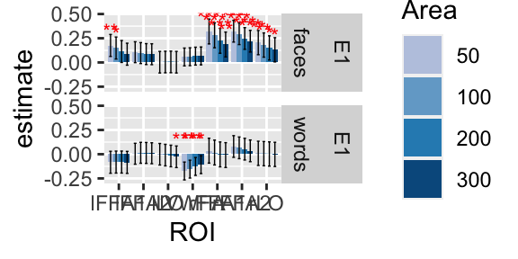

```r
ggplot(filter(df_area_uni, Exp=="E1", contrast=="intact - exchange"),
       aes(x = ROI, y = estimate, fill = Area)) +
  geom_col(position = position_dodge()) +
  geom_errorbar(aes(ymin=lower.CL, ymax=upper.CL), size = 0.25,
                position=position_dodge2(width=0.5, padding=0.5)) +
  facet_grid(rows=vars(Exp, FaceWord)) +
  geom_text(aes(y = y_sig, label = sig), size = 3, color="red",
            position = position_dodge(width=.9)) + # add starts to the significant columns
  scale_fill_manual(values=c("#bdc9e1", "#74a9cf", "#2b8cbe", "#045a8d")) +
  # papaja::theme_apa() +
  NULL
```

```r
# ggsave("E1_area_uni_intact-exchange.pdf", width = 8, height = 4)
```

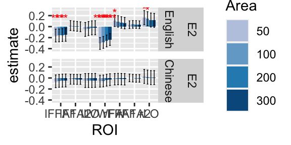

```r
ggplot(filter(df_area_uni, Exp=="E2", contrast=="intact - exchange"),
       aes(x = ROI, y = estimate, fill = Area)) +
  geom_col(position = position_dodge()) +
  geom_errorbar(aes(ymin=lower.CL, ymax=upper.CL), size = 0.25,
                position=position_dodge2(width=0.5, padding=0.5)) +
  facet_grid(rows=vars(Exp, FaceWord)) +
  geom_text(aes(y = y_sig, label = sig), size = 3, color="red",
            position = position_dodge(width=.9)) + # add starts to the significant columns
  scale_fill_manual(values=c("#bdc9e1", "#74a9cf", "#2b8cbe", "#045a8d")) +
  # papaja::theme_apa() +
  NULL
```

```r
# ggsave("E2_area_uni_intact-exchange.pdf", width = 8, height = 4)
```

#### 4.1.1.2 part 1 - part 2

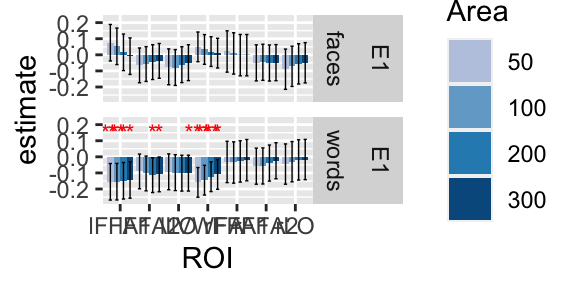

```r
ggplot(filter(df_area_uni, Exp=="E1", contrast=="top - bottom"),
       aes(x = ROI, y = estimate, fill = Area)) +
  geom_col(position = position_dodge()) +
  geom_errorbar(aes(ymin=lower.CL, ymax=upper.CL), size = 0.25,
                position=position_dodge2(width=0.5, padding=0.5)) +
  facet_grid(rows=vars(Exp, FaceWord)) +
  geom_text(aes(y = y_sig, label = sig), size = 3, color="red",
            position = position_dodge(width=.9)) + # add starts to the significant columns
  scale_fill_manual(values=c("#bdc9e1", "#74a9cf", "#2b8cbe", "#045a8d")) +
  # papaja::theme_apa() +
  NULL
```

```r
# ggsave("E1_area_uni_part1-2.pdf", width = 8, height = 4)
```

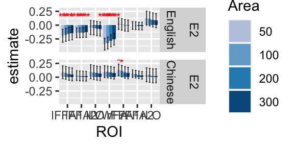

```r
ggplot(filter(df_area_uni, Exp=="E2", contrast=="top - bottom"),
       aes(x = ROI, y = estimate, fill = Area)) +
  geom_col(position = position_dodge()) +
  geom_errorbar(aes(ymin=lower.CL, ymax=upper.CL), size = 0.25,
                position=position_dodge2(width=0.5, padding=0.5)) +
  facet_grid(rows=vars(Exp, FaceWord)) +
  geom_text(aes(y = y_sig, label = sig), size = 3, color="red",
            position = position_dodge(width=.9)) + # add starts to the significant columns
  scale_fill_manual(values=c("#bdc9e1", "#74a9cf", "#2b8cbe", "#045a8d")) +
  # papaja::theme_apa() +
  NULL
```

```r
# ggsave("E2_area_uni_part1-2.pdf", width = 8, height = 4)
```

### 4.1.2 Decoding

```r
df_area_decoding <- rbind(
  one_decode_area_agg_E1_FFA1 %>% mutate(ROI="FFA1", Exp = "E1"),
  one_decode_area_agg_E1_FFA2 %>% mutate(ROI="FFA2", Exp = "E1"),
  one_decode_area_agg_E1_VWFA %>% mutate(ROI="VWFA", Exp = "E1"),
  one_decode_area_agg_E1_LO %>% mutate(ROI="LO", Exp = "E1"),
  one_decode_area_agg_E2_FFA1 %>% mutate(ROI="FFA1", Exp = "E2"),
  one_decode_area_agg_E2_FFA2 %>% mutate(ROI="FFA2", Exp = "E2"),
  one_decode_area_agg_E2_VWFA %>% mutate(ROI="VWFA", Exp = "E2"),
  one_decode_area_agg_E2_LO %>% mutate(ROI="LO", Exp = "E2")
) %>%
  mutate(Area = factor(Area),
         ROI = paste0(substr(Hemisphere, 1,1), ROI),
         sig = sig_ast(p),
         sigcolor = sig_colors(p))
```

#### 4.1.2.1 Intact vs. exchange

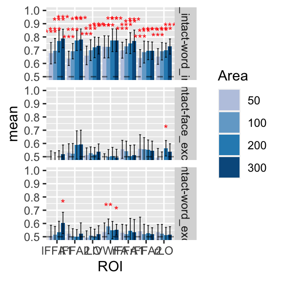

```r
ggplot(filter(df_area_decoding, Exp=="E1", ClassifyPair %in% c("face_intact-word_intact",
                                                               "face_intact-face_exchange",
                                                               "word_intact-word_exchange")),
       aes(x = ROI, y = mean, fill = Area)) +
  geom_col(position = position_dodge()) +
  geom_errorbar(aes(ymin=lower.CL, ymax=upper.CL), size = 0.25,
                position=position_dodge2(width=0.5, padding=0.5)) +
  facet_grid(rows=vars(ClassifyPair)) +
  geom_text(aes(y = mean+0.15, label = sig), size = 3, color="red",
            position = position_dodge(width=.9)) + # add starts to the significant columns
  coord_cartesian(ylim = c(0.5, 1)) +
  scale_fill_manual(values=c("#bdc9e1", "#74a9cf", "#2b8cbe", "#045a8d")) +
  geom_hline(yintercept = 0.5, linetype="dashed", alpha =0.5) +
  # papaja::theme_apa() +
  NULL
```

```r
# ggsave("E1_area_decoding_intact-exchange.pdf", width=8, height = 6)
```

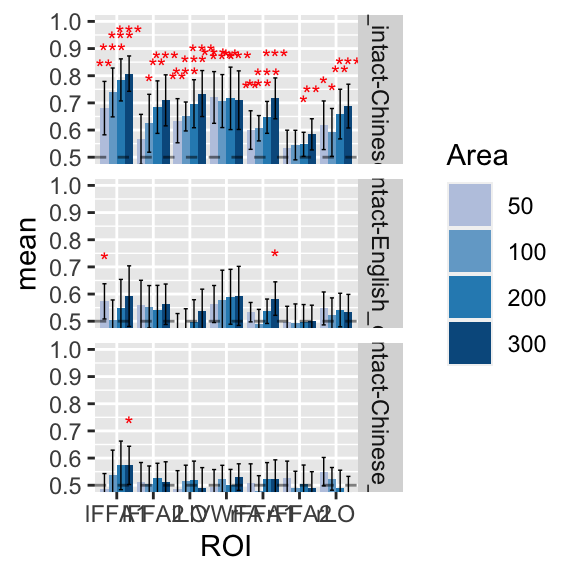

```r
ggplot(filter(df_area_decoding, Exp=="E2", ClassifyPair %in% c("English_intact-Chinese_intact",
                                                               "English_intact-English_exchange",
                                                               "Chinese_intact-Chinese_exchange")),
       aes(x = ROI, y = mean, fill = Area)) +
  geom_col(position = position_dodge()) +
  geom_errorbar(aes(ymin=lower.CL, ymax=upper.CL), size = 0.25,
                position=position_dodge2(width=0.5, padding=0.5)) +
  facet_grid(rows=vars(ClassifyPair)) +
  geom_text(aes(y = mean+0.15, label = sig), size = 3, color="red",
            position = position_dodge(width=.9)) + # add starts to the significant columns
  coord_cartesian(ylim = c(0.5, 1)) +
  scale_fill_manual(values=c("#bdc9e1", "#74a9cf", "#2b8cbe", "#045a8d")) +
  geom_hline(yintercept = 0.5, linetype="dashed", alpha =0.5) +
  # papaja::theme_apa() +
  NULL
```

```r
# ggsave("E2_area_decoding_intact-exchange.pdf", width=8, height = 6)
```